# Practical Pandas, Matplotlib and Seaborn Training

## Data Cleaning, Data Manipulation and Data Visualization - A Complete Hands-On Course

**Prepared by: Kajola Gbenga** **Data Scientist & AI Engineer**

### About this notebook

This notebook is a complete, line-by-line practical course built around one deliberately messy retail sales dataset (`retail_sales_raw.csv`, also available as `retail_sales_training.xlsx`). Every technique is demonstrated on real data with real problems, not on a toy example, so that each idea can be taught, explained and reproduced in a classroom.

Read the markdown cell above each code cell first - it explains, line by line, what the code below it does and why. Then run the code cell and study the output.

## 0. Setup - importing the libraries we need

**Line by line:**

- `import pandas as pd` loads the pandas library, the core tool for tabular data in Python, and gives it the short alias `pd`.
- `import numpy as np` loads NumPy, which pandas is built on top of, and which we use directly for numeric operations such as `np.where` and `np.select`.
- `import matplotlib.pyplot as plt` loads Matplotlib's plotting interface, aliased as `plt`.
- `import seaborn as sns` loads Seaborn, a statistical plotting library built on top of Matplotlib, aliased as `sns`.
- `%matplotlib inline` is a notebook "magic command" that tells Jupyter to render charts directly inside the notebook.
- `pd.set_option(...)` widens how many columns and rows pandas prints, so wide tables are not truncated while we teach.
- `sns.set_theme(...)` sets a consistent, readable visual style for every chart in the notebook.
- `warnings.filterwarnings('ignore')` silences noisy, non-critical warnings so the teaching output stays clean.

```python
import pandas as pd
import numpy as np
import matplotlib.pyplot as plt
import matplotlib.ticker as mticker
import seaborn as sns
import warnings

warnings.filterwarnings('ignore')

%matplotlib inline

pd.set_option('display.max_columns', 60)
pd.set_option('display.width', 160)
pd.set_option('display.max_rows', 100)

sns.set_theme(style='whitegrid', palette='deep')
plt.rcParams['figure.figsize'] = (10, 6)
plt.rcParams['axes.titlesize'] = 14
plt.rcParams['axes.titleweight'] = 'bold'

print('Libraries loaded. pandas:', pd.__version__, '| numpy:', np.__version__)
```

```
Libraries loaded. pandas: 3.0.2 | numpy: 2.4.4
```

# PART 1 - Loading the data and first exploration

We will load the raw CSV file. The same data also exists as an Excel workbook (`retail_sales_training.xlsx`), and we will show how to read that format too.

### 1.1 Reading a CSV file

**Line by line:**

- `pd.read_csv('retail_sales_raw.csv')` reads a comma separated file from disk into a pandas `DataFrame`, pandas' main table object.
- We assign the result to `df`, the variable we will clean and analyse for the rest of the notebook.

```python
df = pd.read_csv('retail_sales_raw.csv')
df.head()
```

|  | RowKey | OrderID | OrderDate | CustomerName | CustomerEmail | Country | ProductCategory | ProductName | Quantity | UnitPrice | Discount | ShippingCost | PaymentMethod | OrderStatus | CustomerGender | CustomerAge | Rating | SalesRep | Notes |
| --- | --- | --- | --- | --- | --- | --- | --- | --- | --- | --- | --- | --- | --- | --- | --- | --- | --- | --- | --- |
| 0 | 1 | ORD-11332 | 07/02/2024 | CHIOMA MUSA | chioma.musa@example.com | france | Groceries | Rice 5kg | 4.0 | $18.36 | 0.25 | 11.74 | CARD | Returned | Male | 38.0 | NaN | D. Bello | Bulk order discount applied |
| 1 | 2 | ORD-11216 | 03/19/2025 | chioma brown | chioma.brown@example.com | NIGERIA | Books | Notebook Pack | 10.0 | $12.89 | 0.15 | 31.76 | Bank Transfer | Cancelled | FEMALE | 31.0 | 3.0 | F. Chukwu | NaN |
| 2 | 3 | ORD-11491 | 28-Jun-2023 | emeka eze | emeka.eze@example.com | INDIA | Home Appliances | Electric Kettle | 11.0 | $213.34 | 0.05 | 13.60 | bank transfer | returned | Female | 33.0 | 4.0 | H. Yusuf | Customer requested gift wrap |
| 3 | 4 | ORD-11157 | 01/07/2025 | Ibrahim Chukwu | ibrahim.chukwu@example.com | Ghana | Groceries | Sugar 1kg | 5.0 | $24.22 | 0.25 | NaN | Mobile Money | Returned | male | -23.0 | 2.0 | E. Okon | NaN |
| 4 | 5 | ORD-10983 | 27-Jul-2025 | Ngozi Okafor | ngozi.okafor@example.com | US | Furniture | Bookshelf | 4.0 | $611.23 | 0.00 | 40.06 | pos | shipped | Female | 53.0 | 1.0 | G. Ibe | NaN |

### 1.2 Reading an Excel file (alternative source)

**Line by line:**

- `pd.read_excel(path, sheet_name='Raw Sales Data')` reads one named sheet from an Excel workbook into a DataFrame.
- `sheet_name=None` (shown commented out) would instead return a dictionary of every sheet in the file, keyed by sheet name - useful when a workbook has several related tables, as ours does (lookup tables for merging, covered in Part 3).

```python
df_from_excel = pd.read_excel('retail_sales_training.xlsx', sheet_name='Raw Sales Data')
print(df_from_excel.shape)
df_from_excel.head(3)

# all_sheets = pd.read_excel('retail_sales_training.xlsx', sheet_name=None)  # returns a dict of DataFrames
```

```
(1539, 19)
```

|  | RowKey | OrderID | OrderDate | CustomerName | CustomerEmail | Country | ProductCategory | ProductName | Quantity | UnitPrice | Discount | ShippingCost | PaymentMethod | OrderStatus | CustomerGender | CustomerAge | Rating | SalesRep | Notes |
| --- | --- | --- | --- | --- | --- | --- | --- | --- | --- | --- | --- | --- | --- | --- | --- | --- | --- | --- | --- |
| 0 | 1 | ORD-11332 | 07/02/2024 | CHIOMA MUSA | chioma.musa@example.com | france | Groceries | Rice 5kg | 4.0 | $18.36 | 0.25 | 11.74 | CARD | Returned | Male | 38.0 | NaN | D. Bello | Bulk order discount applied |
| 1 | 2 | ORD-11216 | 03/19/2025 | chioma brown | chioma.brown@example.com | NIGERIA | Books | Notebook Pack | 10.0 | $12.89 | 0.15 | 31.76 | Bank Transfer | Cancelled | FEMALE | 31.0 | 3.0 | F. Chukwu | NaN |
| 2 | 3 | ORD-11491 | 28-Jun-2023 | emeka eze | emeka.eze@example.com | INDIA | Home Appliances | Electric Kettle | 11.0 | $213.34 | 0.05 | 13.60 | bank transfer | returned | Female | 33.0 | 4.0 | H. Yusuf | Customer requested gift wrap |

### 1.3 Basic shape and structure

**Line by line:**

- `df.shape` returns a tuple `(rows, columns)`, the size of the table.
- `df.columns` lists every column name.
- `df.index` shows the row index (row labels).
- `df.dtypes` shows the data type pandas inferred for every column - this is the single most important first check in any cleaning project, because a column that *should* be numeric but was inferred as `object` (text) tells you immediately that it contains dirty values.

```python
print('Shape (rows, columns):', df.shape)
print()
print('Columns:', list(df.columns))
print()
print('Index:', df.index)
```

```
Shape (rows, columns): (1539, 19)

Columns: ['RowKey', 'OrderID', 'OrderDate', 'CustomerName', 'CustomerEmail', 'Country', 'ProductCategory', 'ProductName', 'Quantity', 'UnitPrice', 'Discount', 'ShippingCost', 'PaymentMethod', 'OrderStatus', 'CustomerGender', 'CustomerAge', 'Rating', 'SalesRep', 'Notes']

Index: RangeIndex(start=0, stop=1539, step=1)
```

```python
df.dtypes
```

```
RowKey               int64
OrderID                str
OrderDate              str
CustomerName           str
CustomerEmail          str
Country                str
ProductCategory        str
ProductName            str
Quantity           float64
UnitPrice              str
Discount           float64
ShippingCost       float64
PaymentMethod          str
OrderStatus            str
CustomerGender         str
CustomerAge        float64
Rating             float64
SalesRep               str
Notes                  str
dtype: object
```

### 1.4 Looking at the data: head, tail, sample

**Line by line:**

- `df.head(10)` shows the first 10 rows.
- `df.tail(5)` shows the last 5 rows.
- `df.sample(5, random_state=1)` shows 5 *random* rows - important, because the first and last rows of a file are often not representative of the messiness hiding in the middle.

```python
df.head(10)
```

|  | RowKey | OrderID | OrderDate | CustomerName | CustomerEmail | Country | ProductCategory | ProductName | Quantity | UnitPrice | Discount | ShippingCost | PaymentMethod | OrderStatus | CustomerGender | CustomerAge | Rating | SalesRep | Notes |
| --- | --- | --- | --- | --- | --- | --- | --- | --- | --- | --- | --- | --- | --- | --- | --- | --- | --- | --- | --- |
| 0 | 1 | ORD-11332 | 07/02/2024 | CHIOMA MUSA | chioma.musa@example.com | france | Groceries | Rice 5kg | 4.0 | $18.36 | 0.25 | 11.74 | CARD | Returned | Male | 38.0 | NaN | D. Bello | Bulk order discount applied |
| 1 | 2 | ORD-11216 | 03/19/2025 | chioma brown | chioma.brown@example.com | NIGERIA | Books | Notebook Pack | 10.0 | $12.89 | 0.15 | 31.76 | Bank Transfer | Cancelled | FEMALE | 31.0 | 3.0 | F. Chukwu | NaN |
| 2 | 3 | ORD-11491 | 28-Jun-2023 | emeka eze | emeka.eze@example.com | INDIA | Home Appliances | Electric Kettle | 11.0 | $213.34 | 0.05 | 13.60 | bank transfer | returned | Female | 33.0 | 4.0 | H. Yusuf | Customer requested gift wrap |
| 3 | 4 | ORD-11157 | 01/07/2025 | Ibrahim Chukwu | ibrahim.chukwu@example.com | Ghana | Groceries | Sugar 1kg | 5.0 | $24.22 | 0.25 | NaN | Mobile Money | Returned | male | -23.0 | 2.0 | E. Okon | NaN |
| 4 | 5 | ORD-10983 | 27-Jul-2025 | Ngozi Okafor | ngozi.okafor@example.com | US | Furniture | Bookshelf | 4.0 | $611.23 | 0.00 | 40.06 | pos | shipped | Female | 53.0 | 1.0 | G. Ibe | NaN |
| 5 | 6 | ORD-11141 | 12/01/2023 | SEGUN ADEYEMI | segun.adeyemi@example.com | India | Fashion | Handbag | 5.0 | $167.43 | 0.10 | 9.00 | Cash | DELIVERED | M | 30.0 | 5.0 | D. Bello | Called before delivery |
| 6 | 7 | ORD-10410 | 03/05/2024 | MARY ADEYEMI | mary.adeyemi@example.com | U.S.A | Home Appliances | Microwave | 8.0 | $186.04 | 0.05 | 18.75 | card | Shipped | female | 31.0 | NaN | D. Bello | Customer requested gift wrap |
| 7 | 8 | ORD-11026 | 24/07/2024 | Khan, Ngozi | ngozi.khan@example.com | United States | Groceries | Cooking Oil 2L | 5.0 | $9.61 | 0.10 | 36.30 | Cash | shipped | m | 19.0 | NaN | H. Yusuf | Called before delivery |
| 8 | 9 | ORD-10173 | 2024-01-29 | FEMI SMITH | femi.smith@example.com | S. Africa | Fashion | Sneakers | 9.0 | $126.68 | 0.25 | 27.65 | mobile money | DELIVERED | m | 39.0 | 2.0 | C. Adeyemi | Fragile item |
| 9 | 10 | ORD-10493 | 08/08/2023 | grace okon | grace.okon@example.com | united states | Electronics | Smartwatch | 7.0 | $932.65 | 0.25 | 36.57 | cash | Shipped | FEMALE | 38.0 | 3.0 | D. Bello | Customer requested gift wrap |

```python
df.tail(5)
```

|  | RowKey | OrderID | OrderDate | CustomerName | CustomerEmail | Country | ProductCategory | ProductName | Quantity | UnitPrice | Discount | ShippingCost | PaymentMethod | OrderStatus | CustomerGender | CustomerAge | Rating | SalesRep | Notes |
| --- | --- | --- | --- | --- | --- | --- | --- | --- | --- | --- | --- | --- | --- | --- | --- | --- | --- | --- | --- |
| 1534 | 1535 | ORD-10212 | 2024-06-20 | BOLA OKAFOR | bola.okafor@example.com | canada | Groceries | Sugar 1kg | 1.0 | $8.35 | 0.00 | 41.07 | card | DELIVERED | Male | 61.0 | NaN | G. Ibe | Bulk order discount applied |
| 1535 | 1536 | ORD-10503 | 16-Feb-2024 | Linda Brown | linda.brown@example.com | kenya | Fashion | Handbag | 2.0 | $23.70 | 0.00 | 11.11 | Cash | Shipped | MALE | 52.0 | 4.0 | C. Adeyemi | Customer requested gift wrap |
| 1536 | 1537 | ORD-10538 | 07-Feb-2025 | IBRAHIM SMITH | ibrahim.smith@example.com | Nigeria | Furniture | Study Desk | 5.0 | $255.05 | 0.25 | 19.23 | card | Returned | m | 46.0 | 4.0 | F. Chukwu | Customer requested gift wrap |
| 1537 | 1538 | ORD-11221 | 01/05/2023 | YETUNDE IBE | yetunde.ibe@example.com | Ghana | Books | Notebook Pack | 5.0 | $24.59 | 0.00 | 17.28 | Mobile Money | shipped | MALE | 49.0 | 5.0 | E. Okon | NaN |
| 1538 | 1539 | ORD-10176 | 30-Dec-2023 | Emeka Garcia | emeka.garcia@example.com | brazil | Furniture | Dining Table | 0.0 | 383.33 | 0.00 | 5.51 | POS | pending | M | 56.0 | 3.0 | F. Chukwu | NaN |

```python
df.sample(5, random_state=1)
```

|  | RowKey | OrderID | OrderDate | CustomerName | CustomerEmail | Country | ProductCategory | ProductName | Quantity | UnitPrice | Discount | ShippingCost | PaymentMethod | OrderStatus | CustomerGender | CustomerAge | Rating | SalesRep | Notes |
| --- | --- | --- | --- | --- | --- | --- | --- | --- | --- | --- | --- | --- | --- | --- | --- | --- | --- | --- | --- |
| 1128 | 1129 | ORD-10246 | 2024-02-04 | Ade Johnson | ade.johnson@example.com | united states | Books | Textbook | 7.0 | $51.94 | 0.00 | 2.29 | POS | delivered | MALE | 44.0 | 3.0 | B. Musa | NaN |
| 1204 | 1205 | ORD-11496 | 03/01/2024 | Chioma Adeyemi | chioma.adeyemi@example.com | brazil | Furniture | Study Desk | 4.0 | $794.00 | 0.00 | 24.76 | Bank Transfer | CANCELLED | female | 19.0 | 1.0 | E. Okon | Called before delivery |
| 953 | 954 | ORD-10412 | 2025/06/23 | Zainab Garcia | zainab.garcia@example.com | Britain | Furniture | Dining Table | 10.0 | $90.73 | 0.10 | 28.28 | Mobile Money | CANCELLED | f | 47.0 | 1.0 | I. Nwosu | Left at door |
| 959 | 960 | ORD-10150 | 2023/01/22 | Grace Williams | grace.williams@example.com | Ghana | Home Appliances | Blender | 11.0 | $29.54 | 0.10 | 17.07 | card | pending | FEMALE | 24.0 | 4.0 | I. Nwosu | Fragile item |
| 190 | 191 | ORD-10411 | 07-Aug-2023 | Halima Okon | halima.okon@example.com | Britain | Furniture | Office Chair | 2.0 | $661.23 | 0.05 | 7.94 | Card | Shipped | female | 25.0 | 1.0 | H. Yusuf | Bulk order discount applied |

### 1.5 Summary information: `info()` and `describe()`

**Line by line:**

- `df.info()` prints the row count, column count, non-null count per column, and dtype per column in one compact report - the fastest way to see where missing data lives.
- `df.describe()` gives summary statistics (count, mean, std, min, quartiles, max) for numeric columns only, by default.
- `df.describe(include='object')` gives the equivalent summary (count, unique, top, freq) for text columns.
- `df.describe(include='all')` combines both, with `NaN` shown where a statistic does not apply.

```python
df.info()
```

```
<class 'pandas.DataFrame'>
RangeIndex: 1539 entries, 0 to 1538
Data columns (total 19 columns):
 #   Column           Non-Null Count  Dtype
---  ------           --------------  -----
 0   RowKey           1539 non-null   int64
 1   OrderID          1535 non-null   str
 2   OrderDate        1499 non-null   str
 3   CustomerName     1535 non-null   str
 4   CustomerEmail    1449 non-null   str
 5   Country          1516 non-null   str
 6   ProductCategory  1535 non-null   str
 7   ProductName      1535 non-null   str
 8   Quantity         1509 non-null   float64
 9   UnitPrice        1499 non-null   str
 10  Discount         1500 non-null   float64
 11  ShippingCost     1483 non-null   float64
 12  PaymentMethod    1535 non-null   str
 13  OrderStatus      1535 non-null   str
 14  CustomerGender   1480 non-null   str
 15  CustomerAge      1484 non-null   float64
 16  Rating           1297 non-null   float64
 17  SalesRep         1535 non-null   str
 18  Notes            954 non-null    str
dtypes: float64(5), int64(1), str(13)
memory usage: 228.6 KB
```

```python
df.describe()
```

|  | RowKey | Quantity | Discount | ShippingCost | CustomerAge | Rating |
| --- | --- | --- | --- | --- | --- | --- |
| count | 1539.000000 | 1509.000000 | 1500.000000 | 1483.000000 | 1484.000000 | 1297.000000 |
| mean | 770.000000 | 5.649437 | 0.111367 | 22.509036 | 35.428571 | 3.041635 |
| std | 444.415346 | 3.532490 | 0.171178 | 13.154342 | 21.761340 | 1.496846 |
| min | 1.000000 | -11.000000 | 0.000000 | 0.140000 | -58.000000 | 1.000000 |
| 25% | 385.500000 | 3.000000 | 0.000000 | 10.935000 | 27.000000 | 2.000000 |
| 50% | 770.000000 | 6.000000 | 0.100000 | 22.490000 | 34.000000 | 3.000000 |
| 75% | 1154.500000 | 9.000000 | 0.200000 | 33.965000 | 42.000000 | 4.000000 |
| max | 1539.000000 | 11.000000 | 1.500000 | 44.980000 | 188.000000 | 8.000000 |

```python
df.describe(include='object')
```

|  | OrderID | OrderDate | CustomerName | CustomerEmail | Country | ProductCategory | ProductName | UnitPrice | PaymentMethod | OrderStatus | CustomerGender | SalesRep | Notes |
| --- | --- | --- | --- | --- | --- | --- | --- | --- | --- | --- | --- | --- | --- |
| count | 1535 | 1499 | 1535 | 1449 | 1516 | 1535 | 1535 | 1499 | 1535 | 1535 | 1480 | 1535 | 954 |
| unique | 1500 | 1226 | 1024 | 394 | 40 | 6 | 31 | 1437 | 11 | 12 | 10 | 10 | 6 |
| top | ORD-10631 | 09/06/2024 | Yetunde Williams | zainab.bello@example.com | Ghana | Groceries | Spaghetti Pack | $310.77 | POS | DELIVERED | Female | C. Adeyemi | Left at door |
| freq | 2 | 6 | 6 | 12 | 77 | 272 | 66 | 3 | 157 | 141 | 171 | 168 | 219 |

### 1.6 Counting missing values and duplicates

**Line by line:**

- `df.isna()` returns a same-shaped DataFrame of `True`/`False` values, `True` where data is missing.
- `.sum()` on that adds the `True` values down each column, giving a missing-value count per column.
- `df.isna().sum().sum()` gives the grand total of missing cells in the whole table.
- `df.duplicated()` flags rows that are an exact repeat of an earlier row.
- `df.duplicated().sum()` counts how many exact duplicate rows exist.

```python
missing_counts = df.isna().sum().sort_values(ascending=False)
print(missing_counts)
print()
print('Total missing cells:', df.isna().sum().sum())
print('Exact duplicate rows:', df.duplicated().sum())
```

```
Notes              585
Rating             242
CustomerEmail       90
CustomerGender      59
ShippingCost        56
CustomerAge         55
OrderDate           40
UnitPrice           40
Discount            39
Quantity            30
Country             23
ProductName          4
OrderID              4
CustomerName         4
ProductCategory      4
OrderStatus          4
PaymentMethod        4
SalesRep             4
RowKey               0
dtype: int64

Total missing cells: 1287
Exact duplicate rows: 0
```

### 1.7 Unique values and value counts

**Line by line:**

- `df['Country'].unique()` lists every distinct value that appears in the `Country` column - this is how we discover that "Nigeria", "nigeria", "NIGERIA" and " Nigeria" are all being treated as different categories.
- `df['Country'].nunique()` counts how many distinct values there are.
- `df['OrderStatus'].value_counts()` counts how often each distinct value occurs, sorted from most to least common - the classic first step for spotting inconsistent categorical data.
- `value_counts(dropna=False)` includes missing values in the count.

```python
print('Unique Country values:', df['Country'].dropna().unique())
print()
print('Number of unique Country values (should be far fewer after cleaning):', df['Country'].nunique())
```

```
Unique Country values: <StringArray>
[              'france',              'NIGERIA',                'INDIA',                'Ghana',                   'US',                'India',
                'U.S.A',        'United States',            'S. Africa',        'united states',                   'UK',             'Nigeria ',
                'KENYA',              'germany',              'england', 'United Arab Emirates',                  'USA',                  'UAE',
               'France',               'canada',               'Canada',               'brazil',         'South Africa',               'CANADA',
                'india',               'Brazil',              'Britain',              'Germany',              'GERMANY',          'Deutschland',
                'ghana',             ' Nigeria',                'Kenya',         'south africa',              'Nigeria',                'kenya',
                 'U.K.',                'U.A.E',       'United Kingdom',              'nigeria']
Length: 40, dtype: str

Number of unique Country values (should be far fewer after cleaning): 40
```

```python
df['OrderStatus'].value_counts(dropna=False)
```

```
OrderStatus
DELIVERED    141
Shipped      137
pending      135
Delivered    135
shipped      134
delivered    133
Pending      132
cancelled    123
Cancelled    122
CANCELLED    119
Returned     113
returned     111
NaN            4
Name: count, dtype: int64
```

```python
df['PaymentMethod'].value_counts(dropna=False)
```

```
PaymentMethod
POS              157
Mobile Money     150
Cash             149
Bank Transfer    143
card             143
cash             143
pos              141
bank transfer    137
mobile money     127
CARD             124
Card             121
NaN                4
Name: count, dtype: int64
```

# PART 2 - Data Cleaning

This is the heart of the course. We will work through every major category of data cleaning in pandas, in the order a real project usually needs them:

2.1 Handling missing values 2.2 Removing duplicate rows 2.3 Fixing data types (numbers stored as text, dates stored as text) 2.4 Cleaning text columns (case, whitespace, inconsistent spelling) 2.5 Standardising categorical values with mapping dictionaries 2.6 Detecting and handling outliers and impossible values 2.7 Renaming and reordering columns 2.8 Final validation of the cleaned dataset

We will build a new, cleaned DataFrame called `clean` step by step, so `df` always stays available as the original untouched raw data for comparison.

### 2.1 Handling missing values

```python
clean = df.copy()

# Step 1: drop rows that are completely blank (every column missing)
before = len(clean)
clean = clean.dropna(how='all')
print(f'Removed {before - len(clean)} fully blank rows. Remaining rows: {len(clean)}')

# Step 2: an OrderID is mandatory - a row without one cannot be reconciled with any sale
before = len(clean)
clean = clean.dropna(subset=['OrderID'])
print(f'Removed {before - len(clean)} rows with a missing OrderID. Remaining rows: {len(clean)}')
```

```
Removed 0 fully blank rows. Remaining rows: 1539
Removed 4 rows with a missing OrderID. Remaining rows: 1535
```

```python
# Demonstrating fillna in three different, common styles

# (a) fill a categorical column with an explicit label
demo_gender = df['CustomerGender'].fillna('Unknown')
print(demo_gender.value_counts(dropna=False))
```

```
CustomerGender
Female     171
M          156
MALE       156
female     152
m          147
F          145
f          141
FEMALE     140
male       138
Male       134
Unknown     59
Name: count, dtype: int64
```

```python
# (b) fill a numeric column with the median (robust to outliers)
demo_rating = df['Rating'].fillna(df['Rating'].median())
print('Missing before:', df['Rating'].isna().sum(), '| Missing after fillna:', demo_rating.isna().sum())
```

```
Missing before: 242 | Missing after fillna: 0
```

```python
# (c) forward fill and interpolate, shown on a small numeric example so the mechanics are visible
example = pd.Series([10, np.nan, np.nan, 40, np.nan, 60])
print('Original:      ', example.tolist())
print('Forward fill:  ', example.ffill().tolist())
print('Backward fill: ', example.bfill().tolist())
print('Interpolated:  ', example.interpolate().tolist())
```

```
Original:       [10.0, nan, nan, 40.0, nan, 60.0]
Forward fill:   [10.0, 10.0, 10.0, 40.0, 40.0, 60.0]
Backward fill:  [10.0, 40.0, 40.0, 40.0, 60.0, 60.0]
Interpolated:   [10.0, 20.0, 30.0, 40.0, 50.0, 60.0]
```

### 2.2 Removing duplicate rows

**Line by line:**

- `clean.duplicated()` flags exact duplicate rows (every column identical).
- `clean.drop_duplicates()` removes exact duplicate rows, keeping the first occurrence by default.
- `clean.drop_duplicates(subset=['OrderID'], keep='first')` removes rows that share the same `OrderID`, even if other columns differ slightly (our "near duplicate, re-keyed" rows) - this is the more realistic real-world rule, because the business key is the order id, not the whole row.
- `keep='last'` keeps the most recent duplicate instead of the first; `keep=False` drops every copy of a duplicated row, keeping none of them.

```python
print('Exact duplicate rows before removal:', clean.duplicated().sum())
clean = clean.drop_duplicates()
print('Exact duplicate rows after removal:', clean.duplicated().sum())

print()
print('Rows sharing an OrderID before removal:', clean.duplicated(subset=['OrderID']).sum())
clean = clean.drop_duplicates(subset=['OrderID'], keep='first')
print('Rows remaining:', len(clean))
```

```
Exact duplicate rows before removal: 0
Exact duplicate rows after removal: 0

Rows sharing an OrderID before removal: 35
Rows remaining: 1500
```

### 2.3 Fixing data types

Several columns look numeric or date-like but were loaded as plain text (`object`), because a few dirty values in each column stopped pandas from inferring the correct type automatically.

**Line by line:**

- `clean['UnitPrice'].str.replace('$', '', regex=False)` removes the currency symbol.
- `.str.replace(',', '', regex=False)` removes thousands separators.
- `pd.to_numeric(series, errors='coerce')` converts text to numbers, turning anything that still cannot be parsed (like the `"N/A"` values) into `NaN` instead of raising an error - this is the safest way to convert a dirty numeric column.
- `pd.to_datetime(series, errors='coerce', dayfirst=False)` parses many different date string formats into real `datetime64` values in one call; unparseable strings become `NaT` (Not a Time), the datetime equivalent of `NaN`.
- `clean['Quantity'].astype('Int64')` casts to pandas' nullable integer type (capital `I`), which, unlike NumPy's `int64`, is allowed to hold missing values.

```python
# Clean the price column: strip currency symbols and commas, then convert to numeric
clean['UnitPrice'] = (
    clean['UnitPrice']
    .astype(str)
    .str.replace('$', '', regex=False)
    .str.replace(',', '', regex=False)
    .str.strip()
)
clean['UnitPrice'] = pd.to_numeric(clean['UnitPrice'], errors='coerce')
print(clean['UnitPrice'].describe())
```

```
count    1464.000000
mean      261.727186
std       339.705389
min         2.180000
25%        32.685000
50%       118.605000
75%       331.647500
max      1496.350000
Name: UnitPrice, dtype: float64
```

```python
# Parse the OrderDate column, which mixes five different date string formats, into real dates
clean['OrderDate'] = pd.to_datetime(clean['OrderDate'], errors='coerce', format='mixed', dayfirst=False)
print(clean['OrderDate'].dtype)
print('Unparseable / missing dates after conversion:', clean['OrderDate'].isna().sum())
clean['OrderDate'].head()
```

```
datetime64[us]
Unparseable / missing dates after conversion: 35
```

```
0   2024-07-02
1   2025-03-19
2   2023-06-28
3   2025-01-07
4   2025-07-27
Name: OrderDate, dtype: datetime64[us]
```

```python
# Convert Quantity and CustomerAge to pandas nullable integer types so NaN can co-exist with whole numbers
clean['Quantity'] = pd.to_numeric(clean['Quantity'], errors='coerce').astype('Int64')
clean['CustomerAge'] = pd.to_numeric(clean['CustomerAge'], errors='coerce').astype('Int64')
clean['Rating'] = pd.to_numeric(clean['Rating'], errors='coerce').astype('Int64')
clean.dtypes
```

```
RowKey                      int64
OrderID                       str
OrderDate          datetime64[us]
CustomerName                  str
CustomerEmail                 str
Country                       str
ProductCategory               str
ProductName                   str
Quantity                    Int64
UnitPrice                 float64
Discount                  float64
ShippingCost              float64
PaymentMethod                 str
OrderStatus                   str
CustomerGender                str
CustomerAge                 Int64
Rating                      Int64
SalesRep                      str
Notes                         str
dtype: object
```

### 2.4 Cleaning text columns

**Line by line:**

- `.str.strip()` removes leading and trailing whitespace (" Nigeria" and "Nigeria " both become "Nigeria").
- `.str.lower()` / `.str.upper()` / `.str.title()` normalise letter case.
- `.str.replace(pattern, repl, regex=True)` performs a find-and-replace, optionally using a regular expression.
- `.str.contains('pattern')` returns True/False for whether each value contains a substring or pattern - useful for flagging malformed values, such as the malformed emails in this data.
- `.str.extract(r'(pattern)')` pulls a substring out of each value using a regex capture group.
- `.str.split(',').str[0]` splits a string on a separator and keeps one piece - used below to fix names stored as "Lastname, Firstname".

```python
# Standardise CustomerName: strip whitespace, fix 'Lastname, Firstname' pattern, then Title Case
def normalise_name(name):
    if pd.isna(name):
        return name
    name = str(name).strip()
    if ',' in name:
        last, first = [p.strip() for p in name.split(',', 1)]
        name = f'{first} {last}'
    return name.title()

clean['CustomerName'] = clean['CustomerName'].apply(normalise_name)
clean['CustomerName'].head(10)
```

```
0       Chioma Musa
1      Chioma Brown
2         Emeka Eze
3    Ibrahim Chukwu
4      Ngozi Okafor
5     Segun Adeyemi
6      Mary Adeyemi
7        Ngozi Khan
8        Femi Smith
9        Grace Okon
Name: CustomerName, dtype: str
```

```python
# Flag malformed emails using str.contains with a simple regex, before deciding how to handle them
valid_email_pattern = r'^[\w\.-]+@[\w\.-]+\.\w+$'
is_valid_email = clean['CustomerEmail'].str.contains(valid_email_pattern, regex=True, na=False)
print('Valid-looking emails:', is_valid_email.sum())
print('Missing or malformed emails:', (~is_valid_email).sum())

# Malformed (non-null but not matching the pattern) emails are set to missing, to be handled like any other NaN
clean.loc[(~is_valid_email) & clean['CustomerEmail'].notna(), 'CustomerEmail'] = np.nan
```

```
Valid-looking emails: 1382
Missing or malformed emails: 118
```

```python
# Clean PaymentMethod and OrderStatus: strip whitespace and standardise casing to Title Case
for col in ['PaymentMethod', 'OrderStatus']:
    clean[col] = clean[col].astype(str).str.strip().str.title()
    clean.loc[clean[col] == 'Nan', col] = np.nan

print(clean['PaymentMethod'].value_counts(dropna=False))
print()
print(clean['OrderStatus'].value_counts(dropna=False))
```

```
PaymentMethod
Card             381
Pos              290
Cash             285
Bank Transfer    275
Mobile Money     269
Name: count, dtype: int64

OrderStatus
Delivered    402
Cancelled    356
Shipped      264
Pending      259
Returned     219
Name: count, dtype: int64
```

### 2.5 Standardising categorical values with a mapping dictionary

Title-casing fixed *some* inconsistency, but country names need a proper lookup dictionary, because "USA", "U.S.A" and "US" do not share a common pattern that `.str.title()` can fix.

**Line by line:**

- We first strip and title-case the raw values to shrink the number of distinct spellings.
- `country_map` is a Python dictionary from every messy variant we still see to one clean, canonical name.
- `clean['Country'].map(country_map)` looks each value up in the dictionary and returns the clean version; any value **not** found in the dictionary becomes `NaN` (a useful side effect that doubles as a validation check).
- `np.where(condition, value_if_true, value_if_false)` is shown as an alternative for a simple two-way recoding.

```python
clean['Country'] = clean['Country'].astype(str).str.strip().str.title()
clean.loc[clean['Country'] == 'Nan', 'Country'] = np.nan

print('Distinct values before dictionary mapping:')
print(sorted(clean['Country'].dropna().unique()))
```

```
Distinct values before dictionary mapping:
['Brazil', 'Britain', 'Canada', 'Deutschland', 'England', 'France', 'Germany', 'Ghana', 'India', 'Kenya', 'Nigeria', 'S. Africa', 'South Africa', 'U.A.E', 'U.K.', 'U.S.A', 'Uae', 'Uk', 'United Arab Emirates', 'United Kingdom', 'United States', 'Us', 'Usa']
```

```python
country_map = {
    'Nigeria': 'Nigeria',
    'United States': 'United States', 'Usa': 'United States', 'U.S.A': 'United States', 'Us': 'United States',
    'United Kingdom': 'United Kingdom', 'Uk': 'United Kingdom', 'U.K.': 'United Kingdom',
    'England': 'United Kingdom', 'Britain': 'United Kingdom',
    'Germany': 'Germany', 'Deutschland': 'Germany',
    'Canada': 'Canada',
    'South Africa': 'South Africa', 'S. Africa': 'South Africa',
    'Kenya': 'Kenya',
    'Ghana': 'Ghana',
    'India': 'India',
    'France': 'France',
    'Brazil': 'Brazil',
    'Uae': 'UAE', 'U.A.E': 'UAE', 'United Arab Emirates': 'UAE',
}

clean['Country'] = clean['Country'].map(country_map)
print('Distinct values after dictionary mapping:')
print(sorted(clean['Country'].dropna().unique()))
print()
print('Rows where Country could not be matched to the dictionary (now NaN):', clean['Country'].isna().sum())
```

```
Distinct values after dictionary mapping:
['Brazil', 'Canada', 'France', 'Germany', 'Ghana', 'India', 'Kenya', 'Nigeria', 'South Africa', 'UAE', 'United Kingdom', 'United States']

Rows where Country could not be matched to the dictionary (now NaN): 18
```

```python
# np.where as a quick alternative for simple two-way recoding, demonstrated on CustomerGender
clean['CustomerGender'] = clean['CustomerGender'].astype(str).str.strip().str.upper().str[0]
clean.loc[~clean['CustomerGender'].isin(['M', 'F']), 'CustomerGender'] = np.nan
clean['CustomerGender'] = np.where(clean['CustomerGender'] == 'M', 'Male',
                            np.where(clean['CustomerGender'] == 'F', 'Female', 'Unknown'))
clean.loc[clean['CustomerGender'] == 'Unknown', 'CustomerGender'] = np.nan
clean['CustomerGender'].value_counts(dropna=False)
```

```
CustomerGender
Female    733
Male      713
NaN        54
Name: count, dtype: int64
```

### 2.6 Detecting and handling outliers and impossible values

**Line by line:**

- The **IQR (interquartile range) method**: compute the 25th percentile (`Q1`) and 75th percentile (`Q3`), then flag anything below `Q1 - 1.5*IQR` or above `Q3 + 1.5*IQR` as a statistical outlier.
- The **domain-knowledge method**: some values are impossible regardless of statistics - a negative age, an age above roughly 110, a discount above 1 (100 percent), or a rating outside 1 to 5. These are cleaned using direct boolean conditions, not statistics.
- `.clip(lower, upper)` caps values at a floor and/or ceiling instead of removing them.

```python
# Domain-knowledge cleaning: values that are impossible no matter their statistical distribution
before_invalid_age = ((clean['CustomerAge'] < 0) | (clean['CustomerAge'] > 110)).sum()
clean.loc[(clean['CustomerAge'] < 0) | (clean['CustomerAge'] > 110), 'CustomerAge'] = pd.NA
print('Impossible ages set to missing:', before_invalid_age)

before_invalid_qty = ((clean['Quantity'] <= 0)).sum()
clean.loc[clean['Quantity'] <= 0, 'Quantity'] = pd.NA
print('Zero or negative quantities set to missing:', before_invalid_qty)

before_invalid_discount = (clean['Discount'] > 1).sum()
clean.loc[clean['Discount'] > 1, 'Discount'] = np.nan
print('Discounts above 100 percent set to missing:', before_invalid_discount)

before_invalid_rating = (~clean['Rating'].between(1, 5) & clean['Rating'].notna()).sum()
clean.loc[~clean['Rating'].between(1, 5), 'Rating'] = pd.NA
print('Ratings outside 1 to 5 set to missing:', before_invalid_rating)
```

```
Impossible ages set to missing: 42
Zero or negative quantities set to missing: 47
Discounts above 100 percent set to missing: 15
Ratings outside 1 to 5 set to missing: 12
```

```python
# Statistical outlier detection with the IQR method, applied to UnitPrice
Q1 = clean['UnitPrice'].quantile(0.25)
Q3 = clean['UnitPrice'].quantile(0.75)
IQR = Q3 - Q1
lower_bound = Q1 - 1.5 * IQR
upper_bound = Q3 + 1.5 * IQR

outliers = clean[(clean['UnitPrice'] < lower_bound) | (clean['UnitPrice'] > upper_bound)]
print(f'IQR bounds: [{lower_bound:.2f}, {upper_bound:.2f}]')
print(f'Number of statistical price outliers: {len(outliers)}')

# Rather than deleting them (they are legitimate premium electronics, not errors), we cap (clip) them
clean['UnitPrice'] = clean['UnitPrice'].clip(lower=0, upper=upper_bound)
```

```
IQR bounds: [-415.76, 780.09]
Number of statistical price outliers: 152
```

### 2.7 Renaming and reordering columns

**Line by line:**

- `clean.rename(columns={...})` renames specific columns using a dictionary of old name to new name.
- `clean.columns = [...]` replaces every column name at once - fast, but you must supply a full list in the correct order.
- `clean[new_order]` reindexes the columns into a chosen order by passing a list of column names.

```python
clean = clean.rename(columns={
    'CustomerAge': 'Age',
    'CustomerGender': 'Gender',
    'CustomerEmail': 'Email',
    'CustomerName': 'Name',
})

new_order = ['OrderID', 'OrderDate', 'Name', 'Email', 'Gender', 'Age', 'Country',
             'ProductCategory', 'ProductName', 'Quantity', 'UnitPrice', 'Discount',
             'ShippingCost', 'PaymentMethod', 'OrderStatus', 'Rating', 'SalesRep', 'Notes']
clean = clean[new_order]
clean.head()
```

|  | OrderID | OrderDate | Name | Email | Gender | Age | Country | ProductCategory | ProductName | Quantity | UnitPrice | Discount | ShippingCost | PaymentMethod | OrderStatus | Rating | SalesRep | Notes |
| --- | --- | --- | --- | --- | --- | --- | --- | --- | --- | --- | --- | --- | --- | --- | --- | --- | --- | --- |
| 0 | ORD-11332 | 2024-07-02 | Chioma Musa | chioma.musa@example.com | Male | 38 | France | Groceries | Rice 5kg | 4 | 18.36 | 0.25 | 11.74 | Card | Returned | <NA> | D. Bello | Bulk order discount applied |
| 1 | ORD-11216 | 2025-03-19 | Chioma Brown | chioma.brown@example.com | Female | 31 | Nigeria | Books | Notebook Pack | 10 | 12.89 | 0.15 | 31.76 | Bank Transfer | Cancelled | 3 | F. Chukwu | NaN |
| 2 | ORD-11491 | 2023-06-28 | Emeka Eze | emeka.eze@example.com | Female | 33 | India | Home Appliances | Electric Kettle | 11 | 213.34 | 0.05 | 13.60 | Bank Transfer | Returned | 4 | H. Yusuf | Customer requested gift wrap |
| 3 | ORD-11157 | 2025-01-07 | Ibrahim Chukwu | ibrahim.chukwu@example.com | Male | <NA> | Ghana | Groceries | Sugar 1kg | 5 | 24.22 | 0.25 | NaN | Mobile Money | Returned | 2 | E. Okon | NaN |
| 4 | ORD-10983 | 2025-07-27 | Ngozi Okafor | ngozi.okafor@example.com | Female | 53 | United States | Furniture | Bookshelf | 4 | 611.23 | 0.00 | 40.06 | Pos | Shipped | 1 | G. Ibe | NaN |

### 2.8 Adding a derived column and final validation of the cleaned dataset

**Line by line:**

- We create `NetSales`, a new numeric column computed from other columns - `Quantity * UnitPrice * (1 - Discount)`. Rows where `Discount` is missing use `.fillna(0)` first, since no discount recorded most often means no discount was applied.
- `clean.isna().sum()` gives a final missing-value report on the cleaned data, for comparison with Part 1.
- `clean.duplicated().sum()` confirms no duplicate rows remain.
- `clean.reset_index(drop=True)` rebuilds the row index as a clean 0..n-1 sequence after all the dropping and filtering above (row numbers were left with gaps).

```python
clean['NetSales'] = (
    clean['Quantity'].astype('Float64')
    * clean['UnitPrice']
    * (1 - clean['Discount'].fillna(0))
)

clean = clean.reset_index(drop=True)

print('Final cleaned shape:', clean.shape)
print()
print('Missing values remaining per column:')
print(clean.isna().sum())
print()
print('Duplicate rows remaining:', clean.duplicated().sum())
```

```
Final cleaned shape: (1500, 19)

Missing values remaining per column:
OrderID              0
OrderDate           35
Name                 0
Email              118
Gender              54
Age                 93
Country             18
ProductCategory      0
ProductName          0
Quantity            73
UnitPrice           36
Discount            50
ShippingCost        50
PaymentMethod        0
OrderStatus          0
Rating             245
SalesRep             0
Notes              570
NetSales           109
dtype: int64

Duplicate rows remaining: 0
```

```python
clean.head(10)
```

|  | OrderID | OrderDate | Name | Email | Gender | Age | Country | ProductCategory | ProductName | Quantity | UnitPrice | Discount | ShippingCost | PaymentMethod | OrderStatus | Rating | SalesRep | Notes | NetSales |
| --- | --- | --- | --- | --- | --- | --- | --- | --- | --- | --- | --- | --- | --- | --- | --- | --- | --- | --- | --- |
| 0 | ORD-11332 | 2024-07-02 | Chioma Musa | chioma.musa@example.com | Male | 38 | France | Groceries | Rice 5kg | 4 | 18.36000 | 0.25 | 11.74 | Card | Returned | <NA> | D. Bello | Bulk order discount applied | 55.08 |
| 1 | ORD-11216 | 2025-03-19 | Chioma Brown | chioma.brown@example.com | Female | 31 | Nigeria | Books | Notebook Pack | 10 | 12.89000 | 0.15 | 31.76 | Bank Transfer | Cancelled | 3 | F. Chukwu | NaN | 109.565 |
| 2 | ORD-11491 | 2023-06-28 | Emeka Eze | emeka.eze@example.com | Female | 33 | India | Home Appliances | Electric Kettle | 11 | 213.34000 | 0.05 | 13.60 | Bank Transfer | Returned | 4 | H. Yusuf | Customer requested gift wrap | 2229.403 |
| 3 | ORD-11157 | 2025-01-07 | Ibrahim Chukwu | ibrahim.chukwu@example.com | Male | <NA> | Ghana | Groceries | Sugar 1kg | 5 | 24.22000 | 0.25 | NaN | Mobile Money | Returned | 2 | E. Okon | NaN | 90.825 |
| 4 | ORD-10983 | 2025-07-27 | Ngozi Okafor | ngozi.okafor@example.com | Female | 53 | United States | Furniture | Bookshelf | 4 | 611.23000 | 0.00 | 40.06 | Pos | Shipped | 1 | G. Ibe | NaN | 2444.92 |
| 5 | ORD-11141 | 2023-12-01 | Segun Adeyemi | segun.adeyemi@example.com | Male | 30 | India | Fashion | Handbag | 5 | 167.43000 | 0.10 | 9.00 | Cash | Delivered | 5 | D. Bello | Called before delivery | 753.435 |
| 6 | ORD-10410 | 2024-03-05 | Mary Adeyemi | mary.adeyemi@example.com | Female | 31 | United States | Home Appliances | Microwave | 8 | 186.04000 | 0.05 | 18.75 | Card | Shipped | <NA> | D. Bello | Customer requested gift wrap | 1413.904 |
| 7 | ORD-11026 | 2024-07-24 | Ngozi Khan | ngozi.khan@example.com | Male | 19 | United States | Groceries | Cooking Oil 2L | 5 | 9.61000 | 0.10 | 36.30 | Cash | Shipped | <NA> | H. Yusuf | Called before delivery | 43.245 |
| 8 | ORD-10173 | 2024-01-29 | Femi Smith | femi.smith@example.com | Male | 39 | South Africa | Fashion | Sneakers | 9 | 126.68000 | 0.25 | 27.65 | Mobile Money | Delivered | 2 | C. Adeyemi | Fragile item | 855.09 |
| 9 | ORD-10493 | 2023-08-08 | Grace Okon | grace.okon@example.com | Female | 38 | United States | Electronics | Smartwatch | 7 | 780.09125 | 0.25 | 36.57 | Cash | Shipped | 3 | D. Bello | Customer requested gift wrap | 4095.479063 |

```python
clean.to_csv('retail_sales_clean.csv', index=False)
print('Cleaned dataset saved to retail_sales_clean.csv')
```

```
Cleaned dataset saved to retail_sales_clean.csv
```

# PART 3 - Data Manipulation

With a clean dataset in hand, this part covers the pandas operations used every day to answer business questions: selecting and filtering, sorting, creating columns, grouping and aggregating, pivoting and reshaping, merging with other tables, binning, ranking, time series operations and multi-index operations.

We load the lookup tables we will need for merging in this part as well.

```python
country_region = pd.read_csv('country_region_lookup.csv')
category_target = pd.read_csv('category_target_lookup.csv')
sales_rep_lookup = pd.read_csv('sales_rep_lookup.csv')

country_region
```

|  | Country | Region | CurrencyCode |
| --- | --- | --- | --- |
| 0 | Nigeria | Africa | NGN |
| 1 | United States | Americas | USD |
| 2 | United Kingdom | Europe | GBP |
| 3 | Germany | Europe | EUR |
| 4 | Canada | Americas | CAD |
| 5 | South Africa | Africa | ZAR |
| 6 | Kenya | Africa | KES |
| 7 | Ghana | Africa | GHS |
| 8 | India | Asia | INR |
| 9 | France | Europe | EUR |
| 10 | Brazil | Americas | BRL |
| 11 | UAE | Middle East | AED |

### 3.1 Selecting and filtering

**Line by line:**

- `clean['Country']` selects a single column as a `Series`.
- `clean[['Country', 'NetSales']]` selects several columns as a `DataFrame` (note the double brackets).
- `clean.loc[row_condition, column_list]` selects by **label** - rows matching a boolean condition, and specific columns.
- `clean.iloc[0:5, 0:3]` selects by **position** - the first 5 rows and first 3 columns, regardless of labels.
- Boolean indexing: `clean[clean['Country'] == 'Nigeria']` keeps only rows where the condition is True.
- `.isin([...])` keeps rows whose value is in a given list.
- `.between(a, b)` keeps rows whose numeric value falls in a range (inclusive by default).
- `.query('expression')` filters using a readable string expression, useful for combining several conditions.

```python
nigeria_sales = clean.loc[clean['Country'] == 'Nigeria', ['OrderID', 'ProductName', 'NetSales']]
print(nigeria_sales.shape)
nigeria_sales.head()
```

```
(113, 3)
```

|  | OrderID | ProductName | NetSales |
| --- | --- | --- | --- |
| 1 | ORD-11216 | Notebook Pack | 109.565 |
| 12 | ORD-10621 | Electric Kettle | 958.392 |
| 48 | ORD-10327 | Sugar 1kg | 30.2 |
| 72 | ORD-10279 | Sneakers | 119.286 |
| 83 | ORD-10701 | Microwave | 685.52 |

```python
clean.iloc[0:5, 0:4]
```

|  | OrderID | OrderDate | Name | Email |
| --- | --- | --- | --- | --- |
| 0 | ORD-11332 | 2024-07-02 | Chioma Musa | chioma.musa@example.com |
| 1 | ORD-11216 | 2025-03-19 | Chioma Brown | chioma.brown@example.com |
| 2 | ORD-11491 | 2023-06-28 | Emeka Eze | emeka.eze@example.com |
| 3 | ORD-11157 | 2025-01-07 | Ibrahim Chukwu | ibrahim.chukwu@example.com |
| 4 | ORD-10983 | 2025-07-27 | Ngozi Okafor | ngozi.okafor@example.com |

```python
top_categories = clean[clean['ProductCategory'].isin(['Electronics', 'Furniture'])]
print(top_categories.shape)

mid_age = clean[clean['Age'].between(25, 40)]
print(mid_age.shape)
```

```
(473, 19)
(749, 19)
```

```python
high_value_delivered = clean.query("OrderStatus == 'Delivered' and NetSales > 500")
print(high_value_delivered.shape)
high_value_delivered.head()
```

```
(180, 19)
```

|  | OrderID | OrderDate | Name | Email | Gender | Age | Country | ProductCategory | ProductName | Quantity | UnitPrice | Discount | ShippingCost | PaymentMethod | OrderStatus | Rating | SalesRep | Notes | NetSales |
| --- | --- | --- | --- | --- | --- | --- | --- | --- | --- | --- | --- | --- | --- | --- | --- | --- | --- | --- | --- |
| 5 | ORD-11141 | 2023-12-01 | Segun Adeyemi | segun.adeyemi@example.com | Male | 30 | India | Fashion | Handbag | 5 | 167.43 | 0.10 | 9.00 | Cash | Delivered | 5 | D. Bello | Called before delivery | 753.435 |
| 8 | ORD-10173 | 2024-01-29 | Femi Smith | femi.smith@example.com | Male | 39 | South Africa | Fashion | Sneakers | 9 | 126.68 | 0.25 | 27.65 | Mobile Money | Delivered | 2 | C. Adeyemi | Fragile item | 855.09 |
| 22 | ORD-10431 | 2024-04-28 | Segun Johnson | segun.johnson@example.com | Male | 54 | United States | Home Appliances | Blender | 11 | 194.56 | 0.00 | 43.79 | Card | Delivered | <NA> | D. Bello | NaN | 2140.16 |
| 31 | ORD-10902 | 2023-07-07 | Bola Brown | bola.brown@example.com | Female | 39 | Canada | Furniture | Dining Table | 8 | 253.21 | 0.10 | 13.24 | Cash | Delivered | <NA> | B. Musa | Fragile item | 1823.112 |
| 61 | ORD-10791 | 2024-09-06 | Sarah Smith | NaN | Male | 27 | Canada | Furniture | Office Chair | 4 | 259.96 | 0.00 | 16.88 | Bank Transfer | Delivered | 3 | A. Okafor | Fragile item | 1039.84 |

### 3.2 Sorting

**Line by line:**

- `clean.sort_values('NetSales', ascending=False)` sorts rows by one column, largest first.
- `clean.sort_values(['Country', 'NetSales'], ascending=[True, False])` sorts by several columns at once, with an independent direction for each.
- `clean.nlargest(5, 'NetSales')` is a fast shortcut for "top 5 rows by this column", equivalent to sorting and taking the head, but clearer to read.
- `clean.nsmallest(5, 'NetSales')` is the same idea for the smallest values.

```python
clean.sort_values('NetSales', ascending=False).head(10)[['OrderID', 'Country', 'ProductName', 'NetSales']]
```

|  | OrderID | Country | ProductName | NetSales |
| --- | --- | --- | --- | --- |
| 1032 | ORD-11197 | Nigeria | Tablet | 8581.00375 |
| 949 | ORD-10726 | UAE | Sofa | 8581.00375 |
| 1417 | ORD-10350 | Ghana | Monitor | 8581.00375 |
| 779 | ORD-11446 | Ghana | Laptop | 8581.00375 |
| 723 | ORD-11132 | Kenya | Smartwatch | 8581.00375 |
| 496 | ORD-11174 | South Africa | Tablet | 8581.00375 |
| 314 | ORD-10511 | UAE | Headphones | 8151.953562 |
| 1295 | ORD-10177 | UAE | Monitor | 7927.59 |
| 1425 | ORD-11155 | Nigeria | Headphones | 7800.9125 |
| 67 | ORD-10817 | South Africa | Monitor | 7800.9125 |

```python
clean.nlargest(5, 'NetSales')[['OrderID', 'ProductName', 'NetSales']]
```

|  | OrderID | ProductName | NetSales |
| --- | --- | --- | --- |
| 496 | ORD-11174 | Tablet | 8581.00375 |
| 723 | ORD-11132 | Smartwatch | 8581.00375 |
| 779 | ORD-11446 | Laptop | 8581.00375 |
| 949 | ORD-10726 | Sofa | 8581.00375 |
| 1032 | ORD-11197 | Tablet | 8581.00375 |

### 3.3 Creating new columns

**Line by line:**

- Direct arithmetic on columns (vectorised) is always the fastest way to create a new column, as shown already with `NetSales`.
- `.apply(function, axis=1)` runs a Python function once per **row**, useful when the logic is too complex for simple arithmetic; slower than vectorised code, so used only when needed.
- `lambda` is a small, unnamed inline function, often paired with `.apply()` or `.map()`.
- `np.select(conditions, choices, default)` evaluates several conditions in order and assigns the matching choice - the vectorised, fast equivalent of a chain of if/elif/else.

```python
clean['OrderYear'] = clean['OrderDate'].dt.year
clean['OrderMonth'] = clean['OrderDate'].dt.month_name()
clean['OrderWeekday'] = clean['OrderDate'].dt.day_name()

clean[['OrderDate', 'OrderYear', 'OrderMonth', 'OrderWeekday']].head()
```

|  | OrderDate | OrderYear | OrderMonth | OrderWeekday |
| --- | --- | --- | --- | --- |
| 0 | 2024-07-02 | 2024.0 | July | Tuesday |
| 1 | 2025-03-19 | 2025.0 | March | Wednesday |
| 2 | 2023-06-28 | 2023.0 | June | Wednesday |
| 3 | 2025-01-07 | 2025.0 | January | Tuesday |
| 4 | 2025-07-27 | 2025.0 | July | Sunday |

```python
# apply + lambda: build a simple 'HighValue' flag row by row
clean['HighValue'] = clean.apply(
    lambda row: 'Yes' if pd.notna(row['NetSales']) and row['NetSales'] > 500 else 'No', axis=1
)
clean['HighValue'].value_counts()
```

```
HighValue
No     811
Yes    689
Name: count, dtype: int64
```

```python
# np.select: assign an age band using several ordered conditions at once (vectorised, fast)
age_float = clean['Age'].astype('Float64')
conditions = [
    (age_float < 25).fillna(False),
    (age_float.between(25, 34)).fillna(False),
    (age_float.between(35, 49)).fillna(False),
    (age_float >= 50).fillna(False),
]
choices = ['Under 25', '25 to 34', '35 to 49', '50 and above']
clean['AgeBand'] = np.select(conditions, choices, default='Unknown')
clean['AgeBand'].value_counts()
```

```
AgeBand
35 to 49        561
25 to 34        458
Under 25        258
50 and above    130
Unknown          93
Name: count, dtype: int64
```

### 3.4 GroupBy and aggregation

**Line by line:**

- `clean.groupby('ProductCategory')['NetSales'].sum()` splits the data into groups by category, then sums `NetSales` within each group - the classic split-apply-combine pattern.
- `.groupby([...])` can group by more than one column at once, producing a hierarchical result.
- `.agg({...})` applies a **different** aggregation to each column in the same call.
- **Named aggregation** (`pd.NamedAgg`) lets you compute several statistics on the same column and give each resulting column a clear, chosen name, avoiding awkward multi-level column headers.
- `.reset_index()` turns the grouped index back into ordinary columns, which is usually easier to read and to plot.

```python
category_sales = clean.groupby('ProductCategory')['NetSales'].sum().sort_values(ascending=False)
category_sales
```

```
ProductCategory
Electronics        699426.105687
Furniture          540463.343063
Home Appliances        246039.26
Fashion               159553.415
Books                 40808.7275
Groceries             27142.1405
Name: NetSales, dtype: Float64
```

```python
country_category_sales = clean.groupby(['Country', 'ProductCategory'])['NetSales'].sum()
country_category_sales.head(10)
```

```
Country  ProductCategory
Brazil   Books                  3491.707
         Electronics        85669.017063
         Fashion               10193.766
         Furniture           49768.77075
         Groceries              4053.795
         Home Appliances        16569.49
Canada   Books                 2755.4065
         Electronics        47828.356125
         Fashion               14751.358
         Furniture          84087.190625
Name: NetSales, dtype: Float64
```

```python
summary = clean.groupby('ProductCategory').agg(
    TotalSales=pd.NamedAgg(column='NetSales', aggfunc='sum'),
    AverageSales=pd.NamedAgg(column='NetSales', aggfunc='mean'),
    OrderCount=pd.NamedAgg(column='OrderID', aggfunc='count'),
    AverageRating=pd.NamedAgg(column='Rating', aggfunc='mean'),
).reset_index().sort_values('TotalSales', ascending=False)

summary
```

|  | ProductCategory | TotalSales | AverageSales | OrderCount | AverageRating |
| --- | --- | --- | --- | --- | --- |
| 1 | Electronics | 699426.105687 | 3238.083823 | 237 | 3.110553 |
| 3 | Furniture | 540463.343063 | 2479.189647 | 236 | 3.095694 |
| 5 | Home Appliances | 246039.26 | 1038.140338 | 254 | 2.910798 |
| 2 | Fashion | 159553.415 | 673.22116 | 254 | 2.927885 |
| 0 | Books | 40808.7275 | 175.899687 | 252 | 2.89372 |
| 4 | Groceries | 27142.1405 | 108.136018 | 267 | 3.077626 |

### 3.5 Pivot tables and cross tabulation

**Line by line:**

- `pd.pivot_table(data, values, index, columns, aggfunc)` reshapes long data into a wide summary grid - rows become `index`, one distinct value per `columns` becomes its own column, and cells hold the aggregated `values`.
- `pd.crosstab(row_series, col_series)` is a specialised pivot table that simply **counts** how often each combination of two categorical variables occurs - the fastest way to build a frequency table between two categories.
- `margins=True` adds row and column totals to either function.

```python
pivot_sales = pd.pivot_table(
    clean, values='NetSales', index='ProductCategory', columns='OrderYear',
    aggfunc='sum', fill_value=0, margins=True, margins_name='Total'
)
pivot_sales
```

| OrderYear ProductCategory | 2023.0 | 2024.0 | 2025.0 | Total |
| --- | --- | --- | --- | --- |
| Books | 13258.617 | 13879.206 | 12551.655 | 39689.478 |
| Electronics | 237245.95225 | 225964.376438 | 216541.38775 | 679751.716437 |
| Fashion | 54445.721 | 57368.645 | 45036.727 | 156851.093 |
| Furniture | 160760.754 | 219021.737687 | 145106.641375 | 524889.133063 |
| Groceries | 8624.084 | 9442.2115 | 8479.7075 | 26546.003 |
| Home Appliances | 94081.398 | 79532.2195 | 59246.4875 | 232860.105 |
| Total | 568416.52625 | 605208.396125 | 486962.606125 | 1660587.5285 |

```python
status_by_category = pd.crosstab(clean['ProductCategory'], clean['OrderStatus'], margins=True)
status_by_category
```

| OrderStatus ProductCategory | Cancelled | Delivered | Pending | Returned | Shipped | All |
| --- | --- | --- | --- | --- | --- | --- |
| Books | 43 | 66 | 47 | 41 | 55 | 252 |
| Electronics | 64 | 70 | 40 | 31 | 32 | 237 |
| Fashion | 68 | 60 | 45 | 40 | 41 | 254 |
| Furniture | 55 | 67 | 40 | 33 | 41 | 236 |
| Groceries | 69 | 76 | 36 | 35 | 51 | 267 |
| Home Appliances | 57 | 63 | 51 | 39 | 44 | 254 |
| All | 356 | 402 | 259 | 219 | 264 | 1500 |

### 3.6 Reshaping data: melt, pivot, stack and unstack

**Line by line:**

- `pd.melt(wide_df, id_vars=[...], value_vars=[...])` converts **wide** data (one column per category) into **long** / tidy data (one row per category), the format most plotting and modelling functions expect.
- `.pivot(index=, columns=, values=)` is the inverse of melt - it turns long data back into wide data (it does not aggregate; the index/columns combination must already be unique).
- `.stack()` moves the innermost column level into the row index, making the table taller and narrower.
- `.unstack()` is the inverse - it moves a row index level out into columns, making the table wider.

```python
wide = pivot_sales.drop(columns='Total').drop(index='Total').reset_index()
wide.columns = wide.columns.astype(str)
wide
```

| OrderYear | ProductCategory | 2023.0 | 2024.0 | 2025.0 |
| --- | --- | --- | --- | --- |
| 0 | Books | 13258.617 | 13879.206 | 12551.655 |
| 1 | Electronics | 237245.95225 | 225964.376438 | 216541.38775 |
| 2 | Fashion | 54445.721 | 57368.645 | 45036.727 |
| 3 | Furniture | 160760.754 | 219021.737687 | 145106.641375 |
| 4 | Groceries | 8624.084 | 9442.2115 | 8479.7075 |
| 5 | Home Appliances | 94081.398 | 79532.2195 | 59246.4875 |

```python
long = pd.melt(wide, id_vars='ProductCategory', var_name='OrderYear', value_name='NetSales')
long.head(10)
```

|  | ProductCategory | OrderYear | NetSales |
| --- | --- | --- | --- |
| 0 | Books | 2023.0 | 13258.617 |
| 1 | Electronics | 2023.0 | 237245.95225 |
| 2 | Fashion | 2023.0 | 54445.721 |
| 3 | Furniture | 2023.0 | 160760.754 |
| 4 | Groceries | 2023.0 | 8624.084 |
| 5 | Home Appliances | 2023.0 | 94081.398 |
| 6 | Books | 2024.0 | 13879.206 |
| 7 | Electronics | 2024.0 | 225964.376438 |
| 8 | Fashion | 2024.0 | 57368.645 |
| 9 | Furniture | 2024.0 | 219021.737687 |

```python
back_to_wide = long.pivot(index='ProductCategory', columns='OrderYear', values='NetSales')
back_to_wide
```

| OrderYear ProductCategory | 2023.0 | 2024.0 | 2025.0 |
| --- | --- | --- | --- |
| Books | 13258.617 | 13879.206 | 12551.655 |
| Electronics | 237245.95225 | 225964.376438 | 216541.38775 |
| Fashion | 54445.721 | 57368.645 | 45036.727 |
| Furniture | 160760.754 | 219021.737687 | 145106.641375 |
| Groceries | 8624.084 | 9442.2115 | 8479.7075 |
| Home Appliances | 94081.398 | 79532.2195 | 59246.4875 |

```python
stacked = back_to_wide.stack()
print(stacked.head(6))
print()
unstacked = stacked.unstack()
unstacked.head()
```

```
ProductCategory  OrderYear
Books            2023.0           13258.617
                 2024.0           13879.206
                 2025.0           12551.655
Electronics      2023.0        237245.95225
                 2024.0       225964.376438
                 2025.0        216541.38775
dtype: Float64
```

| OrderYear ProductCategory | 2023.0 | 2024.0 | 2025.0 |
| --- | --- | --- | --- |
| Books | 13258.617 | 13879.206 | 12551.655 |
| Electronics | 237245.95225 | 225964.376438 | 216541.38775 |
| Fashion | 54445.721 | 57368.645 | 45036.727 |
| Furniture | 160760.754 | 219021.737687 | 145106.641375 |
| Groceries | 8624.084 | 9442.2115 | 8479.7075 |

### 3.7 Merging, joining and concatenating

**Line by line:**

- `pd.merge(left, right, on='key', how='left')` combines two tables on a shared key column, the same idea as a SQL join. `how` controls which rows survive:
  - `'inner'` keeps only keys present in **both** tables.
  - `'left'` keeps every row of the left table, filling with `NaN` where the right table has no match.
  - `'right'` keeps every row of the right table.
  - `'outer'` keeps every key from either table.
- `left.join(right)` is a convenience method for merging on the index instead of a column.
- `pd.concat([df1, df2])` stacks tables - `axis=0` (default) stacks rows on top of each other; `axis=1` places tables side by side, aligning on the index.

```python
merged = clean.merge(country_region, on='Country', how='left')
merged = merged.merge(category_target, on='ProductCategory', how='left')
merged = merged.merge(sales_rep_lookup, on='SalesRep', how='left')

print(merged.shape)
merged[['OrderID', 'Country', 'Region', 'CurrencyCode', 'ProductCategory',
        'CategoryManager', 'SalesRep', 'Team']].head()
```

```
(1500, 30)
```

|  | OrderID | Country | Region | CurrencyCode | ProductCategory | CategoryManager | SalesRep | Team |
| --- | --- | --- | --- | --- | --- | --- | --- | --- |
| 0 | ORD-11332 | France | Europe | EUR | Groceries | Grace Umeh | D. Bello | South |
| 1 | ORD-11216 | Nigeria | Africa | NGN | Books | Paul Danjuma | F. Chukwu | East |
| 2 | ORD-11491 | India | Asia | INR | Home Appliances | Ifeoma Nwachukwu | H. Yusuf | West |
| 3 | ORD-11157 | Ghana | Africa | GHS | Groceries | Grace Umeh | E. Okon | East |
| 4 | ORD-10983 | United States | Americas | USD | Furniture | Femi Alade | G. Ibe | West |

```python
# inner vs left vs outer, demonstrated on two small example tables
left_tbl = pd.DataFrame({'key': ['A', 'B', 'C'], 'left_val': [1, 2, 3]})
right_tbl = pd.DataFrame({'key': ['B', 'C', 'D'], 'right_val': [20, 30, 40]})

print('inner join:')
print(pd.merge(left_tbl, right_tbl, on='key', how='inner'))
print()
print('left join:')
print(pd.merge(left_tbl, right_tbl, on='key', how='left'))
print()
print('outer join:')
print(pd.merge(left_tbl, right_tbl, on='key', how='outer'))
```

```
inner join:
  key  left_val  right_val
0   B         2         20
1   C         3         30

left join:
```

```
  key  left_val  right_val
0   A         1        NaN
1   B         2       20.0
2   C         3       30.0

outer join:
  key  left_val  right_val
0   A       1.0        NaN
1   B       2.0       20.0
2   C       3.0       30.0
3   D       NaN       40.0
```

```python
# concat: stacking two slices of the same table back together (axis=0, the default)
first_half = clean.iloc[:5]
second_half = clean.iloc[5:10]
stacked_rows = pd.concat([first_half, second_half], axis=0)
print(stacked_rows.shape)
```

```
(10, 24)
```

### 3.8 Binning numeric data with cut and qcut

**Line by line:**

- `pd.cut(series, bins=[...], labels=[...])` groups numeric values into bins with **boundaries you choose** - equal-width or custom-width ranges.
- `pd.qcut(series, q=4, labels=[...])` groups numeric values into bins that each contain roughly the **same number of rows** (quantiles) - useful for building balanced segments such as spending quartiles.

```python
clean['SalesBand'] = pd.cut(
    clean['NetSales'], bins=[0, 100, 300, 700, np.inf],
    labels=['Small (0-100)', 'Medium (100-300)', 'Large (300-700)', 'Very Large (700+)']
)
clean['SalesBand'].value_counts().sort_index()
```

```
SalesBand
Small (0-100)        259
Medium (100-300)     312
Large (300-700)      225
Very Large (700+)    595
Name: count, dtype: int64
```

```python
clean['SpendQuartile'] = pd.qcut(clean['NetSales'].rank(method='first'), q=4,
                                  labels=['Q1 - Lowest', 'Q2', 'Q3', 'Q4 - Highest'])
clean['SpendQuartile'].value_counts().sort_index()
```

```
SpendQuartile
Q1 - Lowest     348
Q2              348
Q3              347
Q4 - Highest    348
Name: count, dtype: int64
```

### 3.9 Ranking and cumulative statistics

**Line by line:**

- `.rank(ascending=False)` assigns a rank to each value, largest = rank 1.
- `.cumsum()` running total; `.cumprod()` running product; `.cummax()` / `.cummin()` running max / min.
- `.diff()` difference from the previous row; `.pct_change()` percentage change from the previous row - both are especially useful once data is sorted by date, for measuring period-over-period change.

```python
category_rank = clean.groupby('ProductCategory')['NetSales'].sum().rank(ascending=False)
category_rank.sort_values()
```

```
ProductCategory
Electronics        1.0
Furniture          2.0
Home Appliances    3.0
Fashion            4.0
Books              5.0
Groceries          6.0
Name: NetSales, dtype: Float64
```

```python
monthly = clean.dropna(subset=['OrderDate']).set_index('OrderDate').sort_index()['NetSales'].resample('MS').sum()
monthly_df = monthly.to_frame('MonthlySales')
monthly_df['CumulativeSales'] = monthly_df['MonthlySales'].cumsum()
monthly_df['MonthOverMonthChangePct'] = monthly_df['MonthlySales'].pct_change() * 100
monthly_df.head(8)
```

| OrderDate | MonthlySales | CumulativeSales | MonthOverMonthChangePct |
| --- | --- | --- | --- |
| 2023-01-01 | 54299.884312 | 54299.884312 | <NA> |
| 2023-02-01 | 55631.755438 | 109931.63975 | 2.452807 |
| 2023-03-01 | 30345.982375 | 140277.622125 | -45.45205 |
| 2023-04-01 | 56868.188062 | 197145.810187 | 87.399397 |
| 2023-05-01 | 50655.274875 | 247801.085063 | -10.925112 |
| 2023-06-01 | 59035.013437 | 306836.0985 | 16.542677 |
| 2023-07-01 | 26038.1755 | 332874.274 | -55.893674 |
| 2023-08-01 | 51102.925188 | 383977.199188 | 96.261544 |

### 3.10 Time series operations

**Line by line:**

- `.dt.year`, `.dt.month`, `.dt.day_name()`, `.dt.quarter` (the `.dt` accessor) pull date parts out of a datetime column.
- `.set_index('OrderDate')` makes the date column the row index, which is required for time-series-specific tools such as resampling.
- `.resample('MS').sum()` groups a datetime-indexed series into calendar buckets ('MS' = month start, 'W' = week, 'Q' = quarter, 'Y' = year) and aggregates each bucket - conceptually a groupby specialised for time.
- `.rolling(window=3).mean()` computes a moving average over a trailing window of periods, smoothing out short-term noise to reveal the underlying trend.

```python
ts = clean.dropna(subset=['OrderDate']).set_index('OrderDate').sort_index()

daily_sales = ts['NetSales'].resample('D').sum()
monthly_sales = ts['NetSales'].resample('MS').sum()
quarterly_sales = ts['NetSales'].resample('QE').sum()

print('Daily series length:', len(daily_sales))
print('Monthly series length:', len(monthly_sales))
print('Quarterly series length:', len(quarterly_sales))

monthly_sales.head()
```

```
Daily series length: 1094
Monthly series length: 36
Quarterly series length: 12
```

```
OrderDate
2023-01-01    54299.884312
2023-02-01    55631.755438
2023-03-01    30345.982375
2023-04-01    56868.188062
2023-05-01    50655.274875
Freq: MS, Name: NetSales, dtype: Float64
```

```python
rolling_avg = monthly_sales.rolling(window=3).mean()
pd.DataFrame({'MonthlySales': monthly_sales, 'ThreeMonthRollingAvg': rolling_avg}).head(8)
```

| OrderDate | MonthlySales | ThreeMonthRollingAvg |
| --- | --- | --- |
| 2023-01-01 | 54299.884312 | NaN |
| 2023-02-01 | 55631.755438 | NaN |
| 2023-03-01 | 30345.982375 | 46759.207375 |
| 2023-04-01 | 56868.188062 | 47615.308625 |
| 2023-05-01 | 50655.274875 | 45956.481771 |
| 2023-06-01 | 59035.013437 | 55519.492125 |
| 2023-07-01 | 26038.1755 | 45242.821271 |
| 2023-08-01 | 51102.925188 | 45392.038042 |

### 3.11 MultiIndex (hierarchical index) basics

**Line by line:**

- Grouping by more than one column produces a **MultiIndex** - an index with more than one level.
- `.loc['Nigeria']` on a MultiIndex selects every row belonging to that outer level.
- `.loc[('Nigeria', 'Electronics')]` selects one specific combination of outer and inner level.
- `.swaplevel()` exchanges which level is outer and which is inner.

```python
multi = clean.groupby(['Country', 'ProductCategory'])['NetSales'].sum()
print(multi.index[:5])
print()
print(multi.loc['Nigeria'])
```

```
MultiIndex([('Brazil',       'Books'),
            ('Brazil', 'Electronics'),
            ('Brazil',     'Fashion'),
            ('Brazil',   'Furniture'),
            ('Brazil',   'Groceries')],
           names=['Country', 'ProductCategory'])

ProductCategory
Books                 3991.7725
Electronics        65361.558812
Fashion              11566.9945
Furniture          25601.654687
Groceries             2150.4005
Home Appliances      20877.6085
Name: NetSales, dtype: Float64
```

```python
print(multi.loc[('Nigeria', 'Electronics')])
print()
multi.swaplevel().sort_index().head()
```

```
65361.5588125
```

```
ProductCategory  Country
Books            Brazil      3491.707
                 Canada     2755.4065
                 France      4586.228
                 Germany    3484.6425
                 Ghana      3211.3165
Name: NetSales, dtype: Float64
```

### 3.12 Applying functions: apply, map and applymap

**Line by line:**

- `Series.map(dict_or_function)` transforms every value in a single column, one value at a time - we already used this for `Country`.
- `DataFrame.apply(function, axis=1)` runs a function once per row (or `axis=0`, once per column).
- `DataFrame.map(function)` (formerly `applymap`) runs a function on **every individual cell** in a DataFrame - shown below formatting every numeric column for display.
- **Vectorised operations are preferred over `apply` whenever possible** - they run in optimised C code rather than a slow Python loop over rows. `apply` is a fallback for logic that truly cannot be expressed with vectorised pandas or NumPy operations.

```python
numeric_preview = clean[['UnitPrice', 'NetSales']].head()
formatted = numeric_preview.map(lambda x: f'{x:,.2f}' if pd.notna(x) else x)
formatted
```

|  | UnitPrice | NetSales |
| --- | --- | --- |
| 0 | 18.36 | 55.08 |
| 1 | 12.89 | 109.56 |
| 2 | 213.34 | 2,229.40 |
| 3 | 24.22 | 90.82 |
| 4 | 611.23 | 2,444.92 |

### 3.13 Exporting the manipulated dataset

**Line by line:**

- `merged.to_csv(path, index=False)` writes the enriched table (after merging in the lookup tables) back out to CSV, without writing the row index as a column.
- `monthly_sales.to_frame().to_excel(path)` writes a time series summary out to Excel for sharing with non-technical stakeholders.

```python
merged.to_csv('retail_sales_merged.csv', index=False)
monthly_sales.to_frame('MonthlySales').to_excel('monthly_sales_summary.xlsx')
print('Exports complete: retail_sales_merged.csv, monthly_sales_summary.xlsx')
```

```
Exports complete: retail_sales_merged.csv, monthly_sales_summary.xlsx
```

# PART 4 - Data Visualization with Matplotlib

Matplotlib is the foundational plotting library in Python - Seaborn (Part 5) is built on top of it. This part works through every major Matplotlib chart type, using the cleaned and merged retail sales data. Each chart is shown with the full code needed to build it, labelled and titled the way a chart intended for a report or a dashboard should be.

We first prepare a few small, reusable summary tables that most of the charts below will plot.

```python
plot_df = merged.dropna(subset=['NetSales', 'OrderDate']).copy()

# Convert pandas nullable dtypes (Int64 / Float64) to plain NumPy dtypes for chart compatibility
for col in ['Age', 'Quantity', 'Rating']:
    plot_df[col] = plot_df[col].astype('float64')
plot_df['NetSales'] = plot_df['NetSales'].astype('float64')

cat_sales = plot_df.groupby('ProductCategory')['NetSales'].sum().sort_values(ascending=False)
monthly_sales_plot = plot_df.set_index('OrderDate').sort_index()['NetSales'].resample('MS').sum()
region_sales = plot_df.groupby('Region')['NetSales'].sum().sort_values(ascending=False)
status_counts = plot_df['OrderStatus'].value_counts()
country_year = plot_df.groupby(['Country', 'OrderYear'])['NetSales'].sum().unstack(fill_value=0)

cat_sales
```

```
ProductCategory
Electronics        679751.716437
Furniture          524889.133063
Home Appliances    232860.105000
Fashion            156851.093000
Books               39689.478000
Groceries           26546.003000
Name: NetSales, dtype: float64
```

### 4.1 Line chart

**Line by line:**

- `fig, ax = plt.subplots(figsize=(...))` creates a figure (the whole canvas) and an axes object (the individual chart) - the recommended, explicit way to build a Matplotlib chart.
- `ax.plot(x, y, marker='o', ...)` draws a line connecting the data points, with a circular marker at each point.
- `ax.set_title / set_xlabel / set_ylabel` label the chart.
- `ax.xaxis.set_major_formatter` and `plt.xticks(rotation=...)` keep date labels readable.
- `fig.tight_layout()` removes wasted whitespace so labels are not cut off.

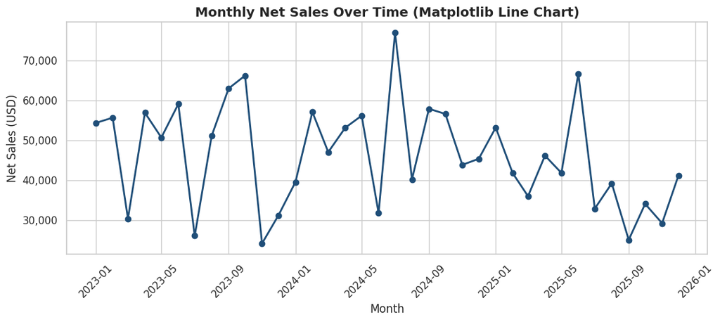

```python
fig, ax = plt.subplots(figsize=(11, 5))
ax.plot(monthly_sales_plot.index, monthly_sales_plot.values, marker='o', color='#1F4E78', linewidth=2)
ax.set_title('Monthly Net Sales Over Time (Matplotlib Line Chart)')
ax.set_xlabel('Month')
ax.set_ylabel('Net Sales (USD)')
ax.yaxis.set_major_formatter(mticker.FuncFormatter(lambda x, _: f'{x:,.0f}'))
plt.xticks(rotation=45)
fig.tight_layout()
plt.show()
```

### 4.2 Vertical bar chart

**Line by line:**

- `ax.bar(categories, values, color=...)` draws one vertical bar per category.
- `ax.bar_label(bars, fmt=...)` writes the value on top of each bar automatically.

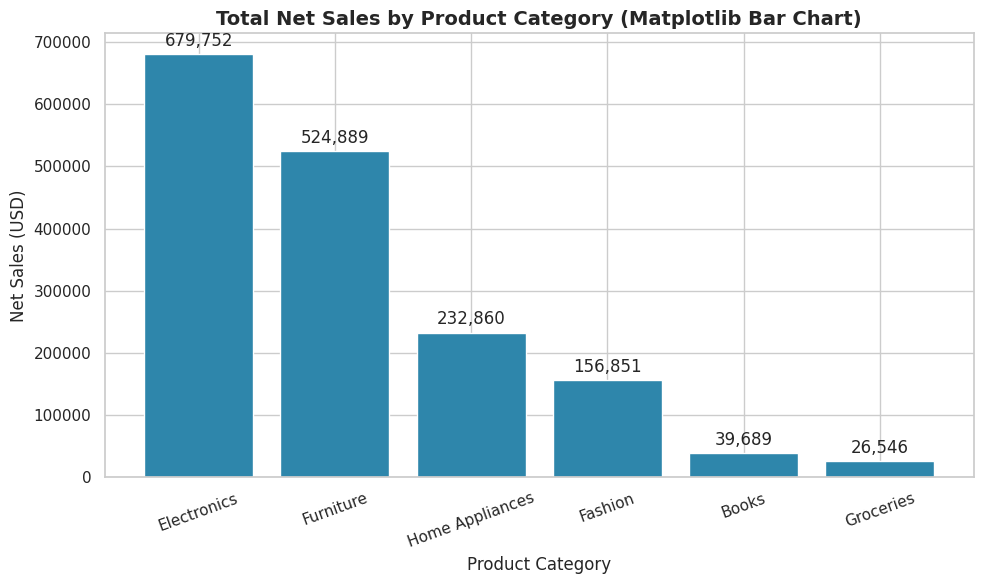

```python
fig, ax = plt.subplots(figsize=(10, 6))
bars = ax.bar(cat_sales.index, cat_sales.values, color='#2E86AB')
ax.set_title('Total Net Sales by Product Category (Matplotlib Bar Chart)')
ax.set_xlabel('Product Category')
ax.set_ylabel('Net Sales (USD)')
ax.bar_label(bars, fmt='{:,.0f}', padding=3)
plt.xticks(rotation=20)
fig.tight_layout()
plt.show()
```

### 4.3 Horizontal bar chart

**Line by line:**

- `ax.barh(categories, values)` draws horizontal bars - often more readable than vertical bars when category labels are long, since the text reads left to right naturally.

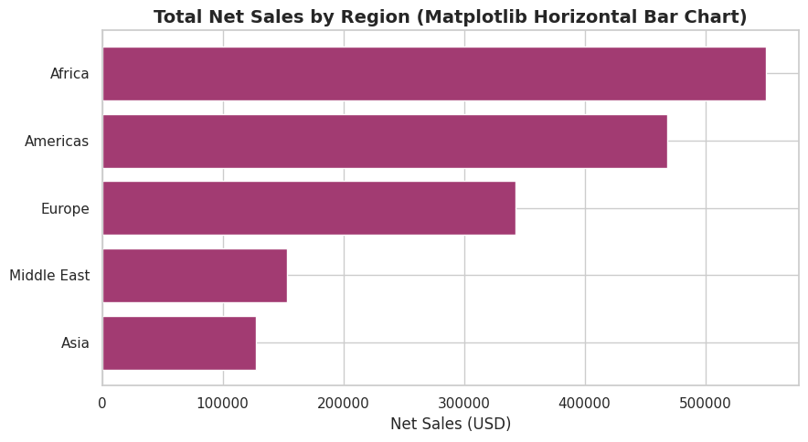

```python
fig, ax = plt.subplots(figsize=(9, 5))
ax.barh(region_sales.index, region_sales.values, color='#A23B72')
ax.set_title('Total Net Sales by Region (Matplotlib Horizontal Bar Chart)')
ax.set_xlabel('Net Sales (USD)')
ax.invert_yaxis()
fig.tight_layout()
plt.show()
```

### 4.4 Stacked bar chart

**Line by line:**

- Plotting a second `ax.bar(..., bottom=first_values)` on top of the first stacks the two series, since `bottom` tells Matplotlib where the new bars should start rather than starting them at zero.

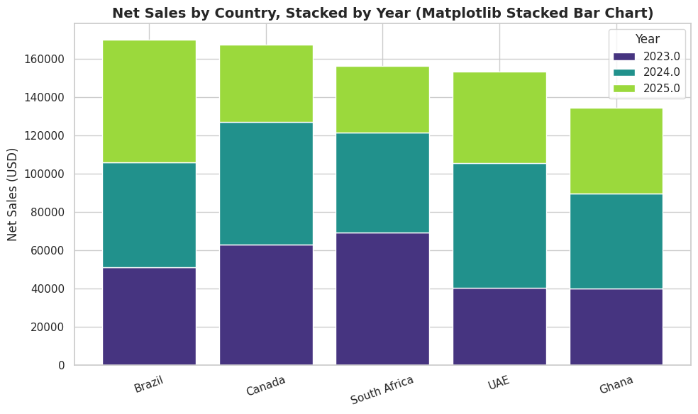

```python
years = country_year.columns.tolist()
top_countries = plot_df.groupby('Country')['NetSales'].sum().nlargest(5).index
stack_data = country_year.loc[top_countries]

fig, ax = plt.subplots(figsize=(10, 6))
bottom = np.zeros(len(stack_data))
colors = plt.cm.viridis(np.linspace(0.15, 0.85, len(years)))
for year, color in zip(years, colors):
    ax.bar(stack_data.index, stack_data[year], bottom=bottom, label=str(year), color=color)
    bottom += stack_data[year].values

ax.set_title('Net Sales by Country, Stacked by Year (Matplotlib Stacked Bar Chart)')
ax.set_ylabel('Net Sales (USD)')
ax.legend(title='Year')
plt.xticks(rotation=20)
fig.tight_layout()
plt.show()
```

### 4.5 Grouped (clustered) bar chart

**Line by line:**

- To place bars for different years side by side rather than stacked, we offset each year's bar positions by a small amount using `np.arange` and a `width` calculated from the number of groups.

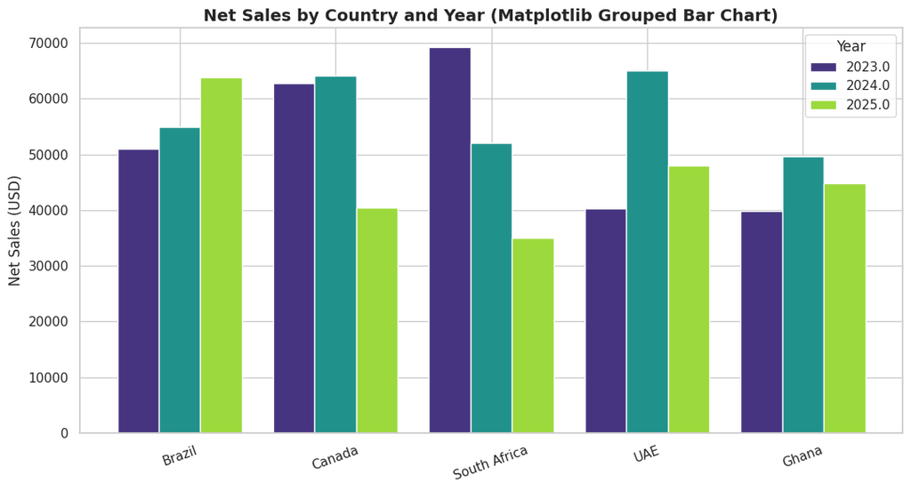

```python
x = np.arange(len(stack_data))
width = 0.8 / len(years)

fig, ax = plt.subplots(figsize=(11, 6))
for i, (year, color) in enumerate(zip(years, colors)):
    ax.bar(x + i * width, stack_data[year], width=width, label=str(year), color=color)

ax.set_title('Net Sales by Country and Year (Matplotlib Grouped Bar Chart)')
ax.set_xticks(x + width * (len(years) - 1) / 2)
ax.set_xticklabels(stack_data.index, rotation=20)
ax.set_ylabel('Net Sales (USD)')
ax.legend(title='Year')
fig.tight_layout()
plt.show()
```

### 4.6 Histogram

**Line by line:**

- `ax.hist(values, bins=30)` splits the numeric range into 30 equal-width bins and counts how many observations fall in each - the standard chart for seeing the shape of a distribution.

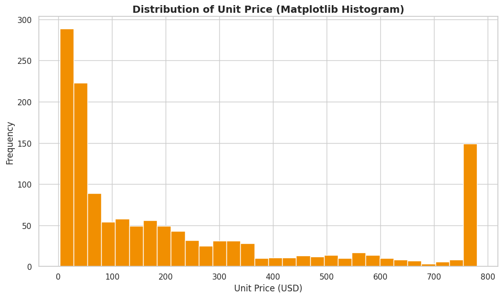

```python
fig, ax = plt.subplots(figsize=(10, 6))
ax.hist(plot_df['UnitPrice'].dropna(), bins=30, color='#F18F01', edgecolor='white')
ax.set_title('Distribution of Unit Price (Matplotlib Histogram)')
ax.set_xlabel('Unit Price (USD)')
ax.set_ylabel('Frequency')
fig.tight_layout()
plt.show()
```

### 4.7 Box plot

**Line by line:**

- `ax.boxplot([...], labels=[...])` draws one box-and-whisker summary (median, quartiles, whiskers, outlier points) per group passed in - a compact way to compare spread and outliers across categories.

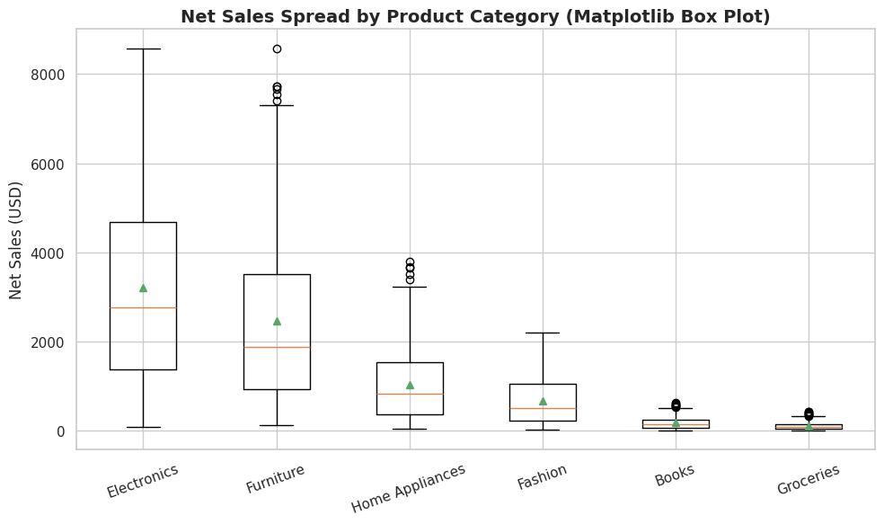

```python
box_data = [plot_df.loc[plot_df['ProductCategory'] == cat, 'NetSales'].dropna()
            for cat in cat_sales.index]

fig, ax = plt.subplots(figsize=(10, 6))
ax.boxplot(box_data, labels=cat_sales.index, showmeans=True)
ax.set_title('Net Sales Spread by Product Category (Matplotlib Box Plot)')
ax.set_ylabel('Net Sales (USD)')
plt.xticks(rotation=20)
fig.tight_layout()
plt.show()
```

### 4.8 Scatter plot (and bubble chart)

**Line by line:**

- `ax.scatter(x, y)` plots one point per row, for seeing the relationship between two numeric variables.
- Passing `s=` (size) mapped from a third numeric variable and `c=` (colour) mapped from a fourth turns the same chart into a **bubble chart**, encoding up to four variables in one plot.

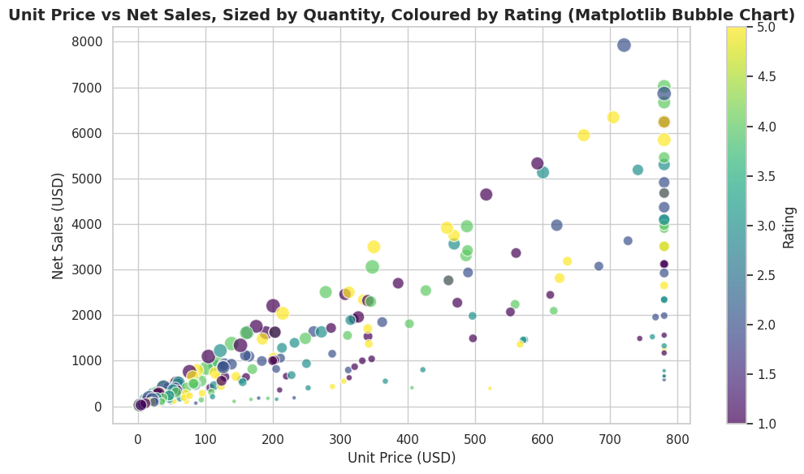

```python
sample = plot_df.dropna(subset=['UnitPrice', 'NetSales', 'Quantity', 'Rating']).sample(
    n=min(300, len(plot_df)), random_state=1)

fig, ax = plt.subplots(figsize=(10, 6))
scatter = ax.scatter(sample['UnitPrice'], sample['NetSales'],
                      s=sample['Quantity'].astype(float) * 15,
                      c=sample['Rating'].astype(float), cmap='viridis', alpha=0.7, edgecolor='white')
ax.set_title('Unit Price vs Net Sales, Sized by Quantity, Coloured by Rating (Matplotlib Bubble Chart)')
ax.set_xlabel('Unit Price (USD)')
ax.set_ylabel('Net Sales (USD)')
cbar = fig.colorbar(scatter, ax=ax)
cbar.set_label('Rating')
fig.tight_layout()
plt.show()
```

### 4.9 Pie chart

**Line by line:**

- `ax.pie(values, labels=..., autopct=...)` draws a pie chart; `autopct` formats the percentage label shown inside each slice. Pie charts read best with five or fewer slices, so we group smaller categories together first where necessary.

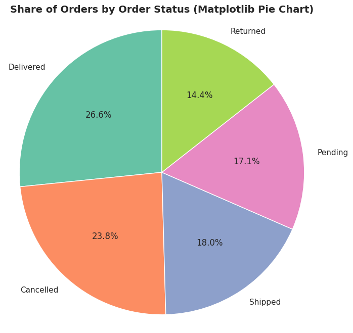

```python
fig, ax = plt.subplots(figsize=(8, 8))
ax.pie(status_counts.values, labels=status_counts.index, autopct='%1.1f%%',
       startangle=90, colors=plt.cm.Set2.colors, wedgeprops={'edgecolor': 'white'})
ax.set_title('Share of Orders by Order Status (Matplotlib Pie Chart)')
ax.axis('equal')
plt.show()
```

### 4.10 Area chart and stacked area chart

**Line by line:**

- `ax.fill_between(x, y)` shades the area under a line - a single-series area chart.
- `ax.stackplot(x, y1, y2, ..., labels=[...])` draws several series stacked on top of one another, useful for showing how a total is composed of parts over time.

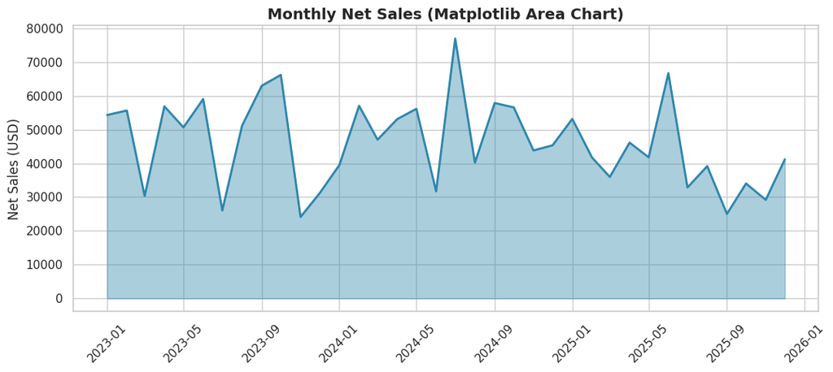

```python
fig, ax = plt.subplots(figsize=(11, 5))
ax.fill_between(monthly_sales_plot.index, monthly_sales_plot.values, color='#2E86AB', alpha=0.4)
ax.plot(monthly_sales_plot.index, monthly_sales_plot.values, color='#2E86AB', linewidth=2)
ax.set_title('Monthly Net Sales (Matplotlib Area Chart)')
ax.set_ylabel('Net Sales (USD)')
plt.xticks(rotation=45)
fig.tight_layout()
plt.show()
```

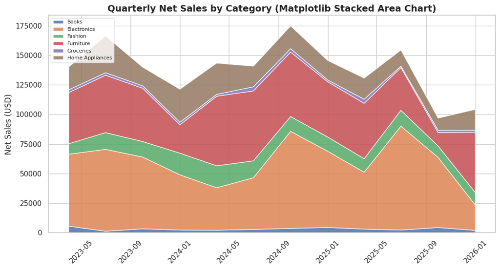

```python
monthly_by_cat = plot_df.set_index('OrderDate').groupby('ProductCategory')['NetSales'].resample('QE').sum().unstack(0).fillna(0)

fig, ax = plt.subplots(figsize=(11, 6))
ax.stackplot(monthly_by_cat.index, [monthly_by_cat[c] for c in monthly_by_cat.columns],
             labels=monthly_by_cat.columns, alpha=0.85)
ax.set_title('Quarterly Net Sales by Category (Matplotlib Stacked Area Chart)')
ax.set_ylabel('Net Sales (USD)')
ax.legend(loc='upper left', fontsize=8)
plt.xticks(rotation=45)
fig.tight_layout()
plt.show()
```

### 4.11 Step plot

**Line by line:**

- `ax.step(x, y, where='mid')` draws a stair-step line instead of a smooth diagonal line between points - appropriate when a value is constant between observations, such as a monthly target that only changes once a month.

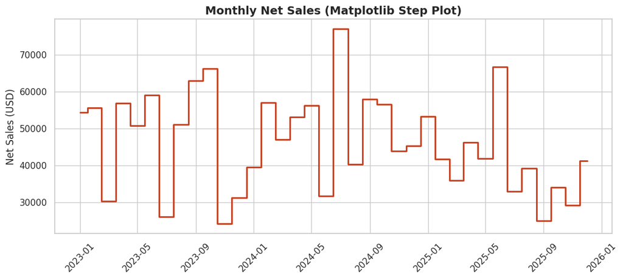

```python
fig, ax = plt.subplots(figsize=(11, 5))
ax.step(monthly_sales_plot.index, monthly_sales_plot.values, where='mid', color='#C73E1D', linewidth=2)
ax.set_title('Monthly Net Sales (Matplotlib Step Plot)')
ax.set_ylabel('Net Sales (USD)')
plt.xticks(rotation=45)
fig.tight_layout()
plt.show()
```

### 4.12 Stem plot

**Line by line:**

- `ax.stem(x, y)` draws a vertical line (stem) from zero up to each data point with a marker at the top - useful for emphasising discrete, individual values rather than a continuous trend.

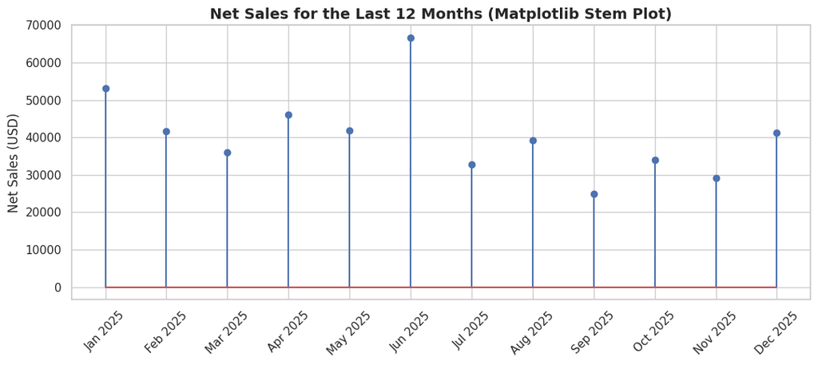

```python
last_12 = monthly_sales_plot.tail(12)
fig, ax = plt.subplots(figsize=(11, 5))
ax.stem(range(len(last_12)), last_12.values)
ax.set_xticks(range(len(last_12)))
ax.set_xticklabels([d.strftime('%b %Y') for d in last_12.index], rotation=45)
ax.set_title('Net Sales for the Last 12 Months (Matplotlib Stem Plot)')
ax.set_ylabel('Net Sales (USD)')
fig.tight_layout()
plt.show()
```

### 4.13 Error bar plot

**Line by line:**

- `ax.errorbar(x, y, yerr=...)` plots a point for each category with a vertical bar showing uncertainty (here, the standard deviation of net sales within each category) - communicating not just the average but how much it varies.

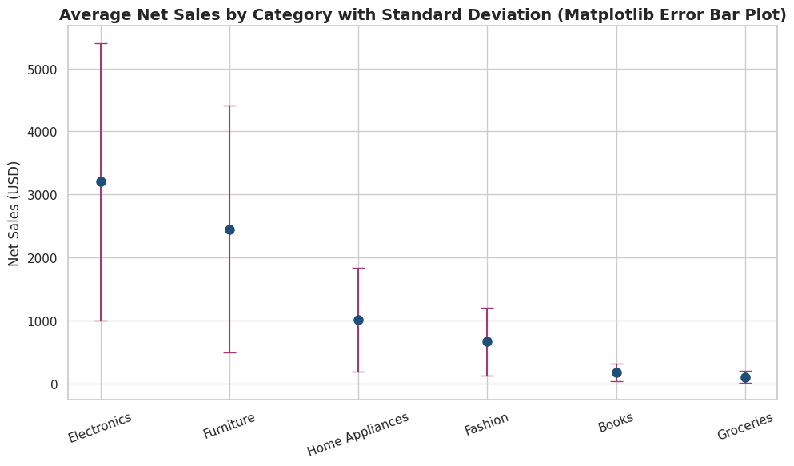

```python
cat_stats = plot_df.groupby('ProductCategory')['NetSales'].agg(['mean', 'std']).sort_values('mean', ascending=False)

fig, ax = plt.subplots(figsize=(10, 6))
ax.errorbar(cat_stats.index, cat_stats['mean'], yerr=cat_stats['std'], fmt='o', capsize=6,
            color='#1F4E78', ecolor='#A23B72', markersize=8)
ax.set_title('Average Net Sales by Category with Standard Deviation (Matplotlib Error Bar Plot)')
ax.set_ylabel('Net Sales (USD)')
plt.xticks(rotation=20)
fig.tight_layout()
plt.show()
```

### 4.14 Dual axis (twin axes) chart

**Line by line:**

- `ax2 = ax1.twinx()` creates a second y-axis that shares the same x-axis as the first - used when plotting two series with very different scales (here, sales in dollars against an order count).

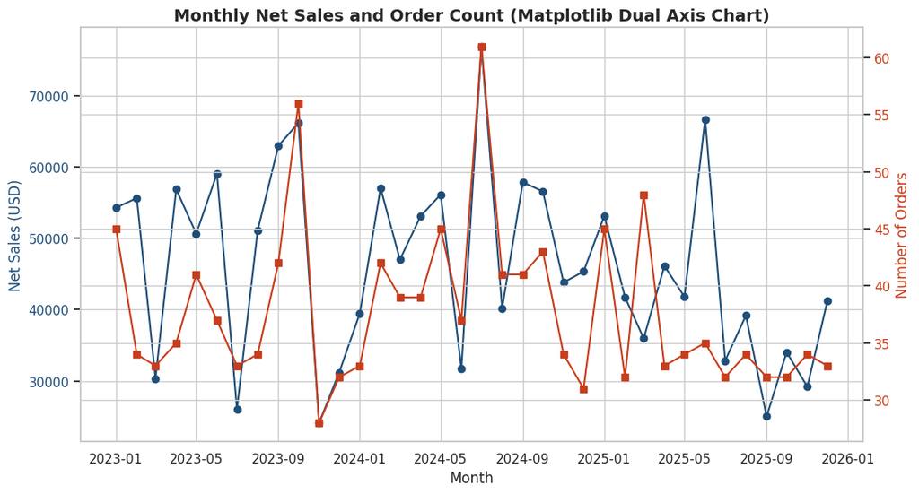

```python
monthly_orders = plot_df.set_index('OrderDate').sort_index()['OrderID'].resample('MS').count()

fig, ax1 = plt.subplots(figsize=(11, 6))
ax1.plot(monthly_sales_plot.index, monthly_sales_plot.values, color='#1F4E78', marker='o', label='Net Sales')
ax1.set_xlabel('Month')
ax1.set_ylabel('Net Sales (USD)', color='#1F4E78')
ax1.tick_params(axis='y', labelcolor='#1F4E78')

ax2 = ax1.twinx()
ax2.plot(monthly_orders.index, monthly_orders.values, color='#C73E1D', marker='s', label='Order Count')
ax2.set_ylabel('Number of Orders', color='#C73E1D')
ax2.tick_params(axis='y', labelcolor='#C73E1D')

ax1.set_title('Monthly Net Sales and Order Count (Matplotlib Dual Axis Chart)')
plt.xticks(rotation=45)
fig.tight_layout()
plt.show()
```

### 4.15 Subplots (multi-panel figure)

**Line by line:**

- `plt.subplots(nrows, ncols, figsize=...)` returns a grid of axes objects at once, letting several related charts share one figure - the basis of a simple dashboard.

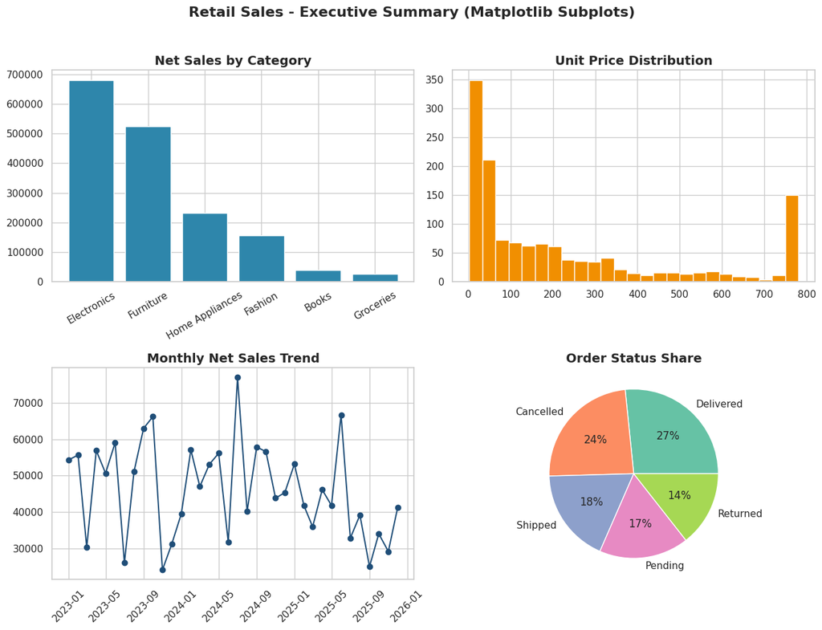

```python
fig, axes = plt.subplots(2, 2, figsize=(13, 10))

axes[0, 0].bar(cat_sales.index, cat_sales.values, color='#2E86AB')
axes[0, 0].set_title('Net Sales by Category')
axes[0, 0].tick_params(axis='x', rotation=30)

axes[0, 1].hist(plot_df['UnitPrice'].dropna(), bins=25, color='#F18F01')
axes[0, 1].set_title('Unit Price Distribution')

axes[1, 0].plot(monthly_sales_plot.index, monthly_sales_plot.values, color='#1F4E78', marker='o')
axes[1, 0].set_title('Monthly Net Sales Trend')
axes[1, 0].tick_params(axis='x', rotation=45)

axes[1, 1].pie(status_counts.values, labels=status_counts.index, autopct='%1.0f%%', colors=plt.cm.Set2.colors)
axes[1, 1].set_title('Order Status Share')

fig.suptitle('Retail Sales - Executive Summary (Matplotlib Subplots)', fontsize=16, fontweight='bold')
fig.tight_layout(rect=[0, 0, 1, 0.96])
plt.show()
```

### 4.16 Saving a chart to a file

**Line by line:**

- `fig.savefig(path, dpi=200, bbox_inches='tight')` exports the current figure to an image file at high resolution, trimming excess whitespace - the standard way to produce a chart for a slide deck or a Word document (used later to build the training manual).

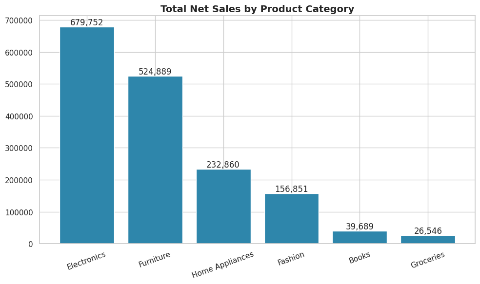

```
Chart saved to chart_category_sales.png
```

```python
fig, ax = plt.subplots(figsize=(10, 6))
bars = ax.bar(cat_sales.index, cat_sales.values, color='#2E86AB')
ax.set_title('Total Net Sales by Product Category')
ax.bar_label(bars, fmt='{:,.0f}')
plt.xticks(rotation=20)
fig.tight_layout()
fig.savefig('chart_category_sales.png', dpi=200, bbox_inches='tight')
plt.show()
print('Chart saved to chart_category_sales.png')
```

# PART 5 - Data Visualization with Seaborn

Seaborn is built on top of Matplotlib and is specialised for statistical graphics: it works directly with tidy (long-format) DataFrames and columns of category labels, and it computes many statistics (means, confidence intervals, regression lines, densities) automatically.

This part works through every major Seaborn chart type on the same cleaned data.

### 5.1 Scatter plot

**Line by line:**

- `sns.scatterplot(data=df, x=, y=, hue=, size=)` plots one point per row directly from a DataFrame; `hue` colours points by a category, `size` scales points by a numeric column - both handled automatically, including drawing the legend.

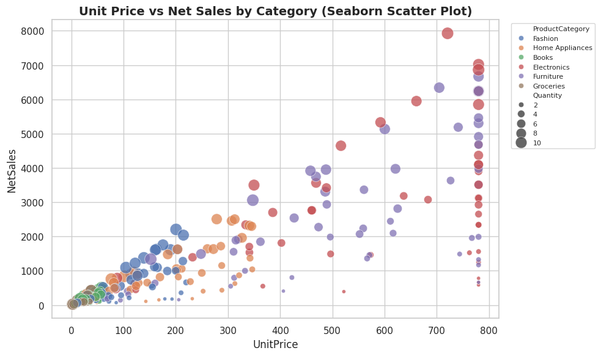

```python
fig, ax = plt.subplots(figsize=(10, 6))
sns.scatterplot(data=sample, x='UnitPrice', y='NetSales', hue='ProductCategory', size='Quantity',
                 sizes=(20, 200), alpha=0.75, ax=ax)
ax.set_title('Unit Price vs Net Sales by Category (Seaborn Scatter Plot)')
ax.legend(bbox_to_anchor=(1.02, 1), loc='upper left', fontsize=8)
fig.tight_layout()
plt.show()
```

### 5.2 Line plot

**Line by line:**

- `sns.lineplot(data=df, x=, y=, hue=)` draws a line per group and, when there are multiple observations per x value, automatically shades a confidence interval band around the line.

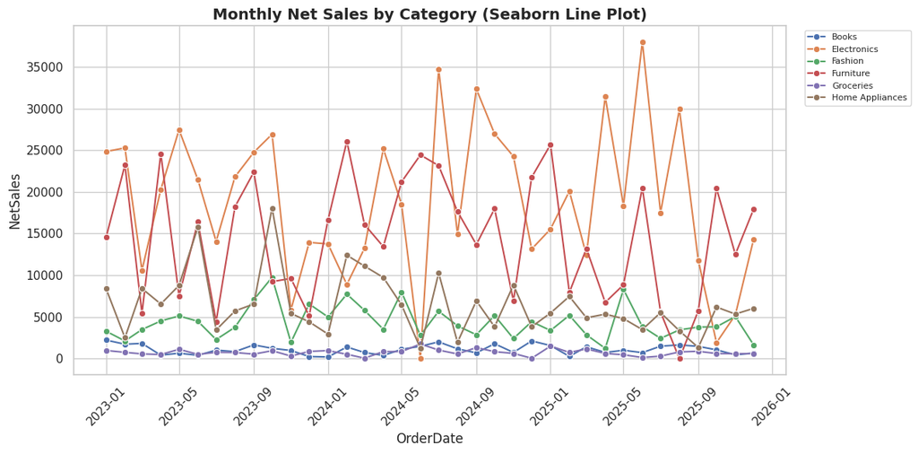

```python
monthly_cat = plot_df.set_index('OrderDate').groupby('ProductCategory')['NetSales'].resample('MS').sum().reset_index()

fig, ax = plt.subplots(figsize=(12, 6))
sns.lineplot(data=monthly_cat, x='OrderDate', y='NetSales', hue='ProductCategory', marker='o', ax=ax)
ax.set_title('Monthly Net Sales by Category (Seaborn Line Plot)')
ax.legend(bbox_to_anchor=(1.02, 1), loc='upper left', fontsize=8)
plt.xticks(rotation=45)
fig.tight_layout()
plt.show()
```

### 5.3 Bar plot

**Line by line:**

- `sns.barplot(data=df, x=, y=, estimator=, errorbar=)` groups the data by `x` and plots the aggregated value (mean, by default) as a bar, with an error bar showing uncertainty around that estimate - Seaborn does the grouping and aggregating internally, unlike Matplotlib's `bar`.

[figure not shown]

```python
fig, ax = plt.subplots(figsize=(10, 6))
sns.barplot(data=plot_df, x='ProductCategory', y='NetSales', estimator='mean', errorbar='sd',
            hue='ProductCategory', legend=False, palette='crest', ax=ax)
ax.set_title('Average Net Sales by Category, with Standard Deviation (Seaborn Bar Plot)')
plt.xticks(rotation=20)
fig.tight_layout()
plt.show()
```

### 5.4 Count plot

**Line by line:**

- `sns.countplot(data=df, x=)` counts how many rows fall into each category and plots the counts as bars - the Seaborn equivalent of `value_counts().plot(kind='bar')`, with cleaner defaults.

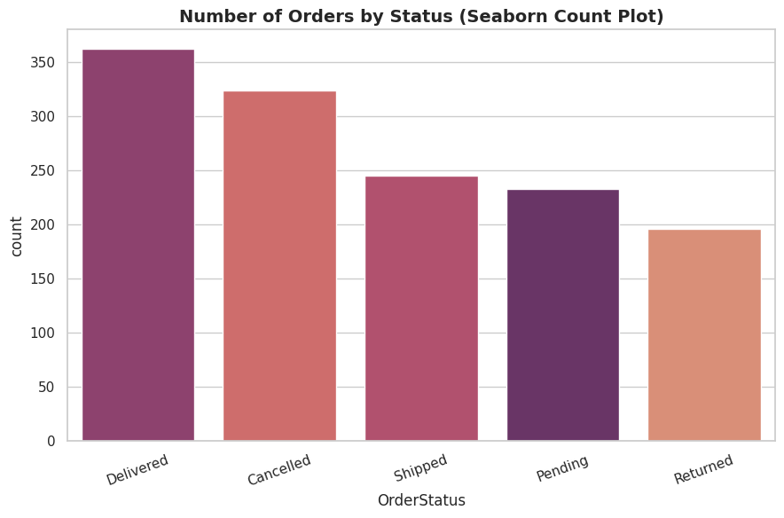

```python
fig, ax = plt.subplots(figsize=(9, 6))
sns.countplot(data=plot_df, x='OrderStatus', order=plot_df['OrderStatus'].value_counts().index,
              hue='OrderStatus', legend=False, palette='flare', ax=ax)
ax.set_title('Number of Orders by Status (Seaborn Count Plot)')
plt.xticks(rotation=20)
fig.tight_layout()
plt.show()
```

### 5.5 Box plot

**Line by line:**

- `sns.boxplot(data=df, x=, y=, hue=)` draws the same box-and-whisker summaries as Matplotlib's `boxplot`, but reads directly from a tidy DataFrame and can split each box further by a `hue` category.

[figure not shown]

```python
fig, ax = plt.subplots(figsize=(11, 6))
sns.boxplot(data=plot_df, x='ProductCategory', y='NetSales', hue='Gender', palette='Set2', ax=ax)
ax.set_title('Net Sales Spread by Category and Gender (Seaborn Box Plot)')
plt.xticks(rotation=20)
fig.tight_layout()
plt.show()
```

### 5.6 Violin plot

**Line by line:**

- `sns.violinplot(...)` combines a box plot with a rotated, mirrored density plot on each side, showing the full shape of the distribution (where values cluster) as well as the summary statistics a box plot shows.

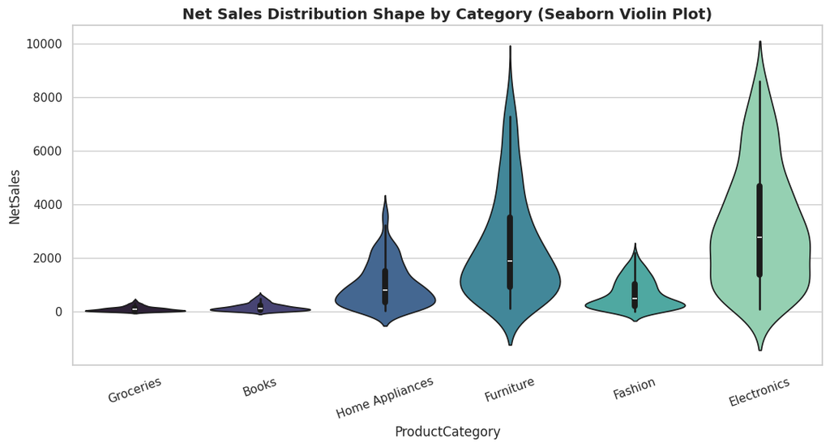

```python
fig, ax = plt.subplots(figsize=(11, 6))
sns.violinplot(data=plot_df, x='ProductCategory', y='NetSales', hue='ProductCategory',
               legend=False, palette='mako', ax=ax)
ax.set_title('Net Sales Distribution Shape by Category (Seaborn Violin Plot)')
plt.xticks(rotation=20)
fig.tight_layout()
plt.show()
```

### 5.7 Strip plot

**Line by line:**

- `sns.stripplot(...)` plots every individual observation as a small, slightly jittered dot along a categorical axis - useful for seeing the raw data points and the sample size behind a summary chart.

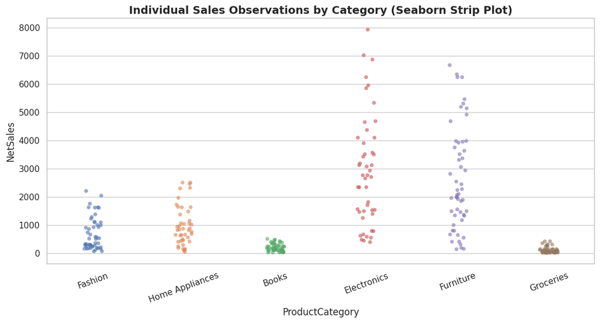

```python
fig, ax = plt.subplots(figsize=(11, 6))
sns.stripplot(data=sample, x='ProductCategory', y='NetSales', hue='ProductCategory',
              legend=False, alpha=0.6, palette='deep', ax=ax)
ax.set_title('Individual Sales Observations by Category (Seaborn Strip Plot)')
plt.xticks(rotation=20)
fig.tight_layout()
plt.show()
```

### 5.8 Swarm plot

**Line by line:**

- `sns.swarmplot(...)` is like a strip plot, but it arranges points so they never overlap, giving a clearer picture of density at each value - best used on a modestly sized sample, as shown here.

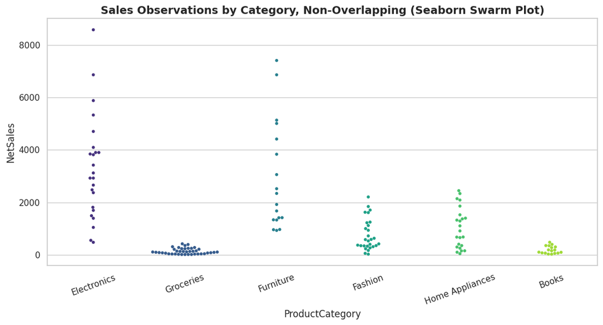

```python
small_sample = plot_df.dropna(subset=['NetSales']).sample(n=min(150, len(plot_df)), random_state=2)

fig, ax = plt.subplots(figsize=(11, 6))
sns.swarmplot(data=small_sample, x='ProductCategory', y='NetSales', hue='ProductCategory',
              legend=False, size=4, palette='viridis', ax=ax)
ax.set_title('Sales Observations by Category, Non-Overlapping (Seaborn Swarm Plot)')
plt.xticks(rotation=20)
fig.tight_layout()
plt.show()
```

### 5.9 Histogram (histplot) with KDE

**Line by line:**

- `sns.histplot(data=df, x=, kde=True, hue=)` draws a histogram and can overlay a smoothed kernel density estimate (KDE) line on top, and can split the histogram by a category automatically.

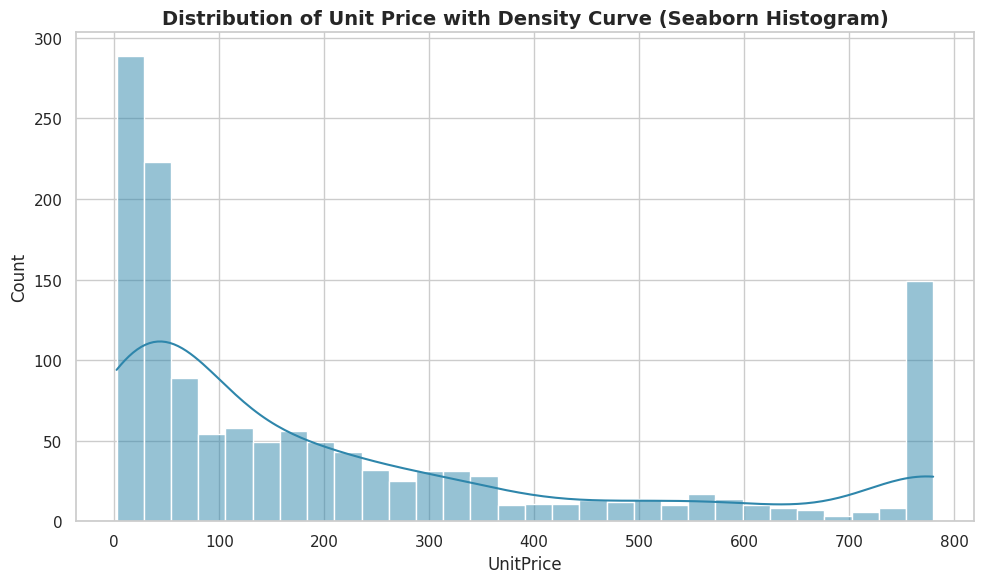

```python
fig, ax = plt.subplots(figsize=(10, 6))
sns.histplot(data=plot_df, x='UnitPrice', kde=True, bins=30, color='#2E86AB', ax=ax)
ax.set_title('Distribution of Unit Price with Density Curve (Seaborn Histogram)')
fig.tight_layout()
plt.show()
```

### 5.10 KDE plot

**Line by line:**

- `sns.kdeplot(data=df, x=, hue=, fill=True)` plots only the smoothed density curve (no bars), making it easy to compare the shape of several distributions overlaid on one chart.

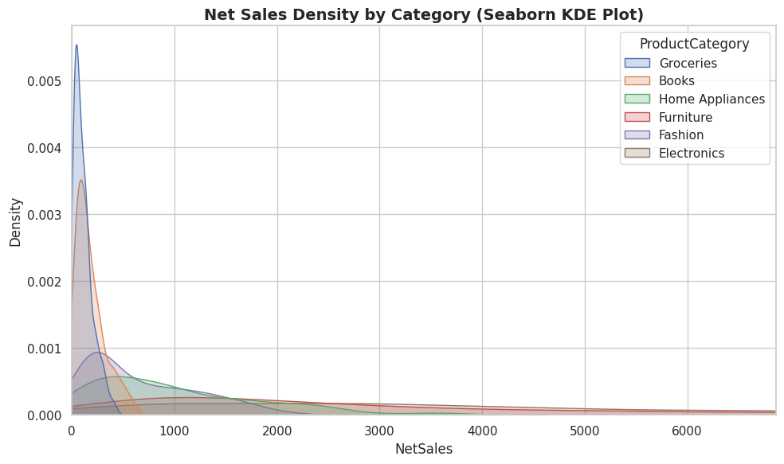

```python
fig, ax = plt.subplots(figsize=(10, 6))
sns.kdeplot(data=plot_df, x='NetSales', hue='ProductCategory', fill=True, alpha=0.25,
            common_norm=False, ax=ax)
ax.set_title('Net Sales Density by Category (Seaborn KDE Plot)')
ax.set_xlim(0, plot_df['NetSales'].quantile(0.98))
fig.tight_layout()
plt.show()
```

### 5.11 ECDF plot

**Line by line:**

- `sns.ecdfplot(data=df, x=)` plots the empirical cumulative distribution function - for any point on the x-axis, the curve shows what proportion of observations are at or below it, a precise alternative to reading percentiles off a histogram.

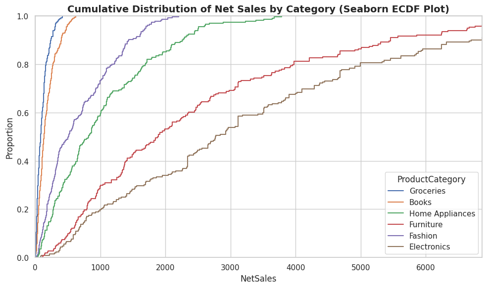

```python
fig, ax = plt.subplots(figsize=(10, 6))
sns.ecdfplot(data=plot_df, x='NetSales', hue='ProductCategory', ax=ax)
ax.set_title('Cumulative Distribution of Net Sales by Category (Seaborn ECDF Plot)')
ax.set_xlim(0, plot_df['NetSales'].quantile(0.98))
fig.tight_layout()
plt.show()
```

### 5.12 Heatmap (correlation matrix)

**Line by line:**

- `df[cols].corr()` computes the pairwise Pearson correlation between numeric columns.
- `sns.heatmap(matrix, annot=True, cmap=...)` colours each cell by its value and writes the numeric value inside the cell - the standard way to visualise a correlation matrix at a glance.

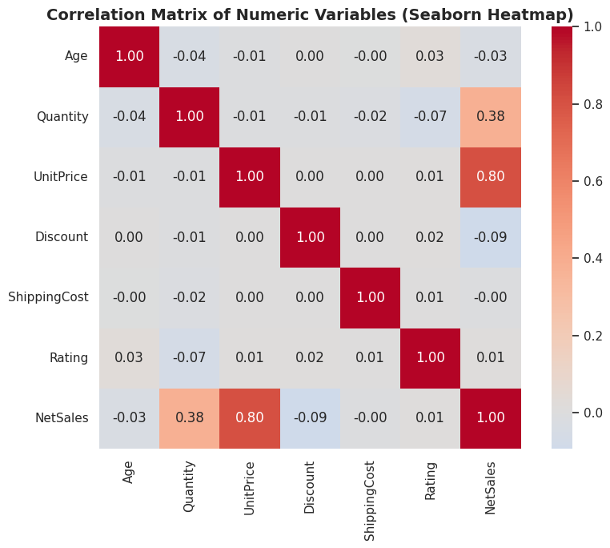

```python
numeric_cols = ['Age', 'Quantity', 'UnitPrice', 'Discount', 'ShippingCost', 'Rating', 'NetSales']
corr_matrix = plot_df[numeric_cols].astype(float).corr()

fig, ax = plt.subplots(figsize=(9, 7))
sns.heatmap(corr_matrix, annot=True, fmt='.2f', cmap='coolwarm', center=0, square=True, ax=ax)
ax.set_title('Correlation Matrix of Numeric Variables (Seaborn Heatmap)')
fig.tight_layout()
plt.show()
```

### 5.13 Heatmap (pivot table of category by month)

**Line by line:**

- The same `sns.heatmap` function is equally useful on any numeric grid, not only correlation matrices - here it visualises a category-by-month sales pivot table, making seasonal patterns visible by colour.

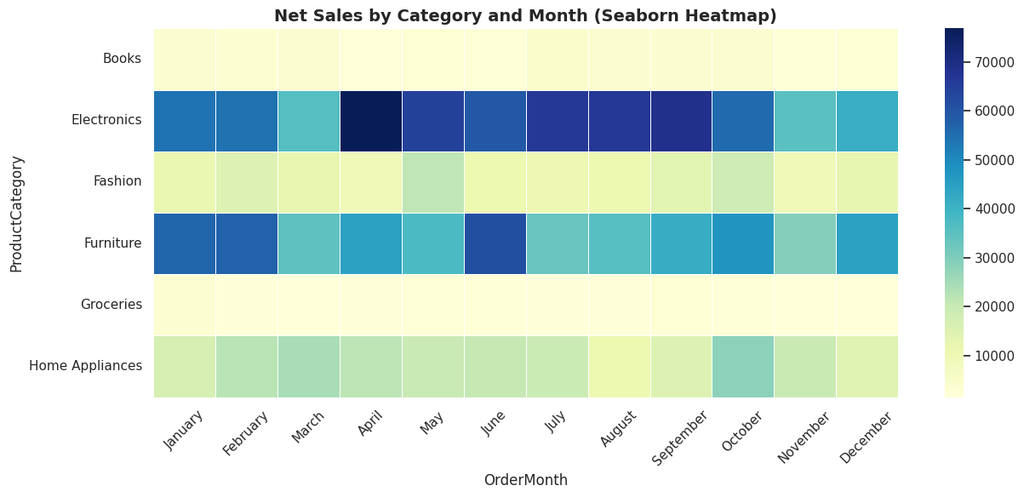

```python
heat_pivot = pd.pivot_table(plot_df, values='NetSales', index='ProductCategory', columns='OrderMonth', aggfunc='sum', fill_value=0)
month_order = ['January','February','March','April','May','June','July','August','September','October','November','December']
heat_pivot = heat_pivot.reindex(columns=[m for m in month_order if m in heat_pivot.columns])

fig, ax = plt.subplots(figsize=(13, 6))
sns.heatmap(heat_pivot, cmap='YlGnBu', linewidths=0.5, ax=ax)
ax.set_title('Net Sales by Category and Month (Seaborn Heatmap)')
plt.xticks(rotation=45)
fig.tight_layout()
plt.show()
```

### 5.14 Regression plot (regplot / lmplot)

**Line by line:**

- `sns.regplot(data=df, x=, y=)` draws a scatter plot with a fitted linear regression line and its confidence interval overlaid - useful for a quick visual read of whether two numeric variables are related.
- `sns.lmplot(...)` does the same, but as a figure-level function that can automatically split the regression into small multiples by a category using `col=` or `row=`.

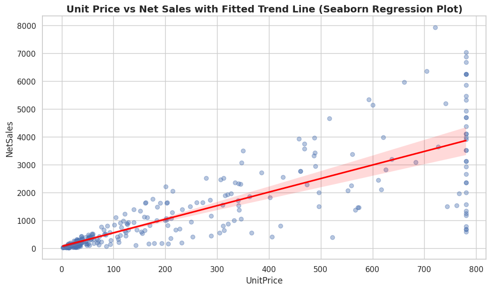

```python
fig, ax = plt.subplots(figsize=(10, 6))
sns.regplot(data=sample, x='UnitPrice', y='NetSales', scatter_kws={'alpha': 0.4}, line_kws={'color': 'red'}, ax=ax)
ax.set_title('Unit Price vs Net Sales with Fitted Trend Line (Seaborn Regression Plot)')
fig.tight_layout()
plt.show()
```

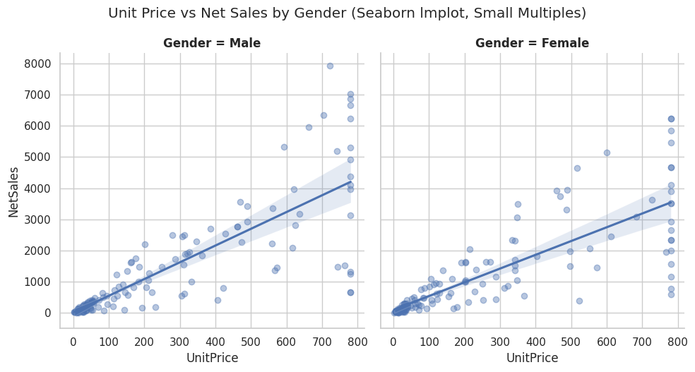

```python
g = sns.lmplot(data=sample, x='UnitPrice', y='NetSales', col='Gender', height=5, aspect=1,
                scatter_kws={'alpha': 0.4})
g.figure.suptitle('Unit Price vs Net Sales by Gender (Seaborn lmplot, Small Multiples)', y=1.05)
plt.show()
```